# Using Machine Learning Methods to Understand Financial Literacy, by G.F.A. Nibbering

This is the R code that is used in the analysis of my master thesis: “Using Machine Learning to Understand Financial Literacy”.

It uses household data from the LISS Panel Data. This is a database that contains much information on Dutch households. Anyone connected to a research institution can contact the LISS Panel and request access to their data. The corresponding data sets that have been used for the analyses in this notebook are references to below.

#Libraries

```r
# This package allows .SAV files to be imported into R
library(haven)

# These packages are useful for data organization
library(dplyr)
library(tidyr)
library(tidyverse)
library(skimr)

# Packages for analysis
library(hdm)
```

#Data Source The data sets used for this anlaysis can be accesed through the following sources:

Asset.12: https://www.dataarchive.lissdata.nl/study_units/view/331 Income.11: https://www.dataarchive.lissdata.nl/study_units/view/260 Income.12: https://www.dataarchive.lissdata.nl/study_units/view/328 Housing.11: https://www.dataarchive.lissdata.nl/study_units/view/220 Personality.11: https://www.dataarchive.lissdata.nl/study_units/view/208 Work.11: https://www.dataarchive.lissdata.nl/study_units/view/244 Integration.11: https://www.dataarchive.lissdata.nl/study_units/view/221 Demographics.11: https://www.dataarchive.lissdata.nl/study_units/view/205 Background.11: https://www.dataarchive.lissdata.nl/study_units/view/322 (English 2011 January) F.Literacy.11: https://www.dataarchive.lissdata.nl/study_units/view/257 Risk.12: https://www.dataarchive.lissdata.nl/study_units/view/320

#Importing the data

```r
# Data on Assets (ca)
Asset.12 <- as.data.frame(read_sav("ca12c_EN_1.0p.sav"))

# Data on Income (ci)
Income.11 <- as.data.frame(read_sav("ci11d_EN_1.0p.sav"))
Income.12 <- as.data.frame(read_sav("ci12e_1.0p_EN.sav"))

# Data on Housing (cd)
Housing.11 <- as.data.frame(read_sav("cd11d_EN_2.0p.sav"))
#Housing.12 <- as.data.frame(read_sav("cd12e_EN_1.0p.sav"))

# Data on Personality (cp)
Personality.11 <- as.data.frame(read_sav("cp11d_1.0p_EN.sav"))

# Data on Work and Schooling (cw)
# Please not the year 2011 was only available in .dta format
Work.11 <- as.data.frame(read_dta("cw11d_EN_1.0p.dta"))

# Data on Social Integration and Leisure (cs)
Integration.11 <- as.data.frame(read_sav("cs11d_EN_3.0p.sav"))

# Data on Religion and Ethnicity
Demographics.11 <- as.data.frame(read_sav("cr11d_EN_1.0p.sav"))

#Background Variables
Background.11 <- as.data.frame(read_sav("avars_201101_EN_2.0p.sav"))
#Background.12 <- as.data.frame(read_sav("avars_201201_EN_2.0p.sav"))

#Financial Literacy specific Data
#F.Capability.10 <- as.data.frame(read_sav("dk10a_EN_1.1p.sav"))
F.Literacy.11 <- as.data.frame(read_sav("ew11a_EN_1.0p.sav"))

#Risk Preferences
Risk.12 <- as.data.frame(read_sav("ga12a_EN_1.0p.sav"))
```

#Data Examination

```r
# Asset.12
na_counter <- sapply(Asset.12, function(x) sum(is.na(x)))
vars <- colnames(Asset.12)

# Extract all variables with NA-values
na_values <- tibble(variables = vars, na_count = na_counter)

# Check na count per variable
na_values %>%
  filter(na_count > 0) %>%
  arrange(desc(na_count))


# Remove NA's from Asset.12
variables_analysis <-
  na_values %>%
  filter(na_count <= (5588*0.05)) %>%
  select(variables) %>%
  pull(variables)

Asset.12 <- Asset.12 %>% select(all_of(variables_analysis))
```

[output not shown]

The same is done for the housing data

```r
# Housing.11
# Count missing cases per variable
na_counter <- sapply(Housing.11, function(x) sum(is.na(x)))
vars <- colnames(Housing.11)

# Extract all variables with NA-values
na_values <- tibble(variables = vars, na_count = na_counter)

# Check na count per variable
na_values %>%
  filter(na_count > 0) %>%
  arrange(desc(na_count))
```

| variables | na_count |
| --- | --- |
| cd11d085 | 3370 |
| cd11d066 | 3367 |
| cd11d084 | 3366 |
| cd11d064 | 3361 |
| cd11d062 | 3343 |
| cd11d072 | 3336 |
| cd11d087 | 3335 |
| cd11d070 | 3326 |
| cd11d063 | 3286 |
| cd11d056 | 3285 |

[output cut: 62 more lines]

```r
# Remove NA's from Housing.11
variables_analysis <-
  na_values %>%
  filter(na_count <= (3371*0.05)) %>%
  select(variables) %>%
  pull(variables)

Housing.11 <- Housing.11 %>% select(all_of(variables_analysis))
```

```r
# Income.11
# Count missing cases per variable
na_counter <- sapply(Income.11, function(x) sum(is.na(x)))
vars <- colnames(Income.11)

# Extract all variables with NA-values
na_values <- tibble(variables = vars, na_count = na_counter)

# Check na count per variable
na_values %>%
  filter(na_count > 0) %>%
  arrange(desc(na_count))
```

| variables | na_count |
| --- | --- |
| ci11d109 | 5240 |
| ci11d336 | 5240 |
| ci11d058 | 5239 |
| ci11d124 | 5239 |
| ci11d334 | 5239 |
| ci11d335 | 5239 |
| ci11d164 | 5239 |
| ci11d057 | 5237 |
| ci11d125 | 5237 |
| ci11d127 | 5237 |

[output cut: 301 more lines]

```r
# Remove NA's from Income.11
variables_analysis <-
  na_values %>%
  filter(na_count <= (5240*0.15)) %>%
  select(variables) %>%
  pull(variables)

Income.11 <- Income.11 %>% select(all_of(variables_analysis))



# Income.12
# Count missing cases per variable
na_counter <- sapply(Income.12, function(x) sum(is.na(x)))
vars <- colnames(Income.12)

# Extract all variables with NA-values
na_values <- tibble(variables = vars, na_count = na_counter)

# Check na count per variable
na_values %>%
  filter(na_count > 0) %>%
  arrange(desc(na_count))
```

| variables | na_count |
| --- | --- |
| ci12e109 | 5761 |
| ci12e334 | 5761 |
| ci12e336 | 5760 |
| ci12e197 | 5760 |
| ci12e118 | 5759 |
| ci12e124 | 5759 |
| ci12e127 | 5759 |
| ci12e332 | 5759 |
| ci12e335 | 5759 |
| ci12e198 | 5759 |

[output cut: 276 more lines]

```r
# Remove NA's from Income.12
variables_analysis <-
  na_values %>%
  filter(na_count <= (5761*0.155)) %>%
  select(variables) %>%
  pull(variables)

Income.12 <- Income.12 %>% select(all_of(variables_analysis))
```

```r
# Integration.11
# Count missing cases per variable
na_counter <- sapply(Integration.11, function(x) sum(is.na(x)))
vars <- colnames(Integration.11)

# Extract all variables with NA-values
na_values <- tibble(variables = vars, na_count = na_counter)

# Check na count per variable
na_values %>%
  filter(na_count > 0) %>%
  arrange(desc(na_count))
```

| variables | na_count |
| --- | --- |
| cs11d225 | 5639 |
| cs11d226 | 5639 |
| cs11d400 | 5639 |
| cs11d179 | 5614 |
| cs11d207 | 5595 |
| cs11d208 | 5595 |
| cs11d391 | 5595 |
| cs11d193 | 5559 |
| cs11d194 | 5559 |
| cs11d384 | 5559 |

[output cut: 387 more lines]

```r
# Remove NA's from Integration.11
variables_analysis <-
  na_values %>%
  filter(na_count <= (5661*0.05)) %>%
  select(variables) %>%
  pull(variables)

Integration.11 <- Integration.11 %>% select(all_of(variables_analysis))
```

```r
# Personality.11
# Count missing cases per variable
na_counter <- sapply(Personality.11, function(x) sum(is.na(x)))
vars <- colnames(Personality.11)

# Extract all variables with NA-values
na_values <- tibble(variables = vars, na_count = na_counter)

# Check na count per variable
na_values %>%
  filter(na_count > 0) %>%
  arrange(desc(na_count))
```

| variables | na_count |
| --- | --- |
| cp11d193 | 125 |
| cp11d187 | 124 |
| cp11d184 | 123 |
| cp11d185 | 123 |
| cp11d186 | 123 |
| cp11d188 | 123 |
| cp11d019 | 116 |
| cp11d010 | 86 |
| cp11d011 | 84 |
| cp11d175 | 51 |

[output cut: 177 more lines]

```r
# Remove NA's from Personality.11
variables_analysis <-
  na_values %>%
  filter(na_count <= (5321*0.05)) %>%
  select(variables) %>%
  pull(variables)

Personality.11 <- Personality.11 %>% select(all_of(variables_analysis))
```

```r
# Work.11
# Count missing cases per variable
na_counter <- sapply(Work.11, function(x) sum(is.na(x)))
vars <- colnames(Work.11)

# Extract all variables with NA-values
na_values <- tibble(variables = vars, na_count = na_counter)

# Check na count per variable
na_values %>%
  filter(na_count > 0) %>%
  arrange(desc(na_count))
```

| variables | na_count |
| --- | --- |
| cw11d174 | 5358 |
| cw11d175 | 5358 |
| cw11d178 | 5358 |
| cw11d179 | 5358 |
| cw11d182 | 5358 |
| cw11d183 | 5358 |
| cw11d186 | 5358 |
| cw11d187 | 5358 |
| cw11d170 | 5357 |
| cw11d171 | 5357 |

[output cut: 448 more lines]

```r
# Remove NA's from Work.11
variables_analysis <-
  na_values %>%
  filter(na_count <= (5358*0.05)) %>%
  select(variables) %>%
  pull(variables)

Work.11 <- Work.11 %>% select(all_of(variables_analysis))
```

```r
# Demographics.11
# Count missing cases per variable
na_counter <- sapply(Demographics.11, function(x) sum(is.na(x)))
vars <- colnames(Demographics.11)

# Extract all variables with NA-values
na_values <- tibble(variables = vars, na_count = na_counter)

# Check na count per variable
na_values %>%
  filter(na_count > 0) %>%
  arrange(desc(na_count))
```

| variables | na_count |
| --- | --- |
| cr11d024 | 5565 |
| cr11d015 | 5535 |
| cr11d023 | 5476 |
| cr11d014 | 5468 |
| cr11d090 | 5337 |
| cr11d005 | 5288 |
| cr11d004 | 5084 |
| cr11d022 | 4635 |
| cr11d013 | 3499 |
| cr11d096 | 2673 |

[output cut: 42 more lines]

```r
# Remove NA's from Demographics.11
variables_analysis <-
  na_values %>%
  filter(na_count <= (5358*0.05)) %>%
  select(variables) %>%
  pull(variables)

Demographics.11 <- Demographics.11 %>% select(all_of(variables_analysis))
```

#Data Transformations

Assets

```r
#Make a dataframe exlcusing survey questions about the survey
Asset.12 <- Asset.12[,1:23]

#Delete variables that describe the same information as other variables
Asset.12$ca12c001 <- NULL
Asset.12$ca12c003 <- NULL
Asset.12$ca12c082 <- NULL
Asset.12$ca12c_m <- NULL

#Changing the variable type of the variables
Asset.12[,1:19] <- as.numeric(unlist(list(Asset.12[,1:19])))

#Changing variables in which 12 corresponds to no to 0
Asset.12$ca12c010[Asset.12$ca12c010 == 2] <- 0
Asset.12$ca12c011[Asset.12$ca12c011 == 2] <- 0
Asset.12$ca12c079[Asset.12$ca12c079 == 2] <- 0
Asset.12$ca12c080[Asset.12$ca12c080 == 2] <- 0
Asset.12$ca12c081[Asset.12$ca12c081 == 2] <- 0
```

```r
# Setting the appropriate variables to as.factor()
Asset.12$ca12c078 <- as.factor(Asset.12$ca12c078)
Asset.12$ca12c005 <- as.factor(Asset.12$ca12c005)
Asset.12$ca12c006 <- as.factor(Asset.12$ca12c006)
Asset.12$ca12c007 <- as.factor(Asset.12$ca12c007)
Asset.12$ca12c008 <- as.factor(Asset.12$ca12c008)
Asset.12$ca12c009 <- as.factor(Asset.12$ca12c009)
Asset.12$ca12c010 <- as.factor(Asset.12$ca12c010)
Asset.12$ca12c011 <- as.factor(Asset.12$ca12c011)
Asset.12$ca12c079 <- as.factor(Asset.12$ca12c079)
Asset.12$ca12c080 <- as.factor(Asset.12$ca12c080)
Asset.12$ca12c081 <- as.factor(Asset.12$ca12c081)
Asset.12$ca12c057 <- as.factor(Asset.12$ca12c057)
Asset.12$ca12c058 <- as.factor(Asset.12$ca12c058)
Asset.12$ca12c059 <- as.factor(Asset.12$ca12c059)
Asset.12$ca12c060 <- as.factor(Asset.12$ca12c060)
Asset.12$ca12c061 <- as.factor(Asset.12$ca12c061)
Asset.12$ca12c062 <- as.factor(Asset.12$ca12c062)
```

Housing

```r
#Make a dataframe that excludes survey questions about the survey
Housing.11 <- Housing.11[,1:34]

#Delete variables that describe the same information as other variables
Housing.11$nohouse_encr <- NULL
Housing.11$cd11d_m <- NULL
Housing.11$cd11d007 <- NULL
Housing.11$cd11d032 <- NULL
Housing.11$cd11d034 <- NULL
Housing.11$cd11d057 <- NULL
Housing.11$cd11d065 <- NULL
Housing.11$cd11d071 <- NULL

#Changing the variable type of the variables
Housing.11[,1:19] <- as.numeric(unlist(list(Housing.11[,1:19])))

#Changing variables in which 12 corresponds to no to 0
Housing.11$cd11d035[Housing.11$cd11d035 == 2] <- 0
Housing.11$cd11d054[Housing.11$cd11d054 == 2] <- 0
Housing.11$cd11d055[Housing.11$cd11d055 == 2] <- 0
Housing.11$cd11d058[Housing.11$cd11d058 == 2] <- 0

# Setting the appropriate variables to as.factor()
Housing.11$cd11d003 <- as.factor(Housing.11$cd11d003)
Housing.11$cd11d035 <- as.factor(Housing.11$cd11d035)
Housing.11$cd11d038 <- as.factor(Housing.11$cd11d038)
Housing.11$cd11d041 <- as.factor(Housing.11$cd11d041)
Housing.11$cd11d042 <- as.factor(Housing.11$cd11d042)
Housing.11$cd11d043 <- as.factor(Housing.11$cd11d043)
Housing.11$cd11d044 <- as.factor(Housing.11$cd11d044)
Housing.11$cd11d045 <- as.factor(Housing.11$cd11d045)
Housing.11$cd11d046 <- as.factor(Housing.11$cd11d046)
Housing.11$cd11d047 <- as.factor(Housing.11$cd11d047)
Housing.11$cd11d048 <- as.factor(Housing.11$cd11d048)
Housing.11$cd11d049 <- as.factor(Housing.11$cd11d049)
Housing.11$cd11d050 <- as.factor(Housing.11$cd11d050)
Housing.11$cd11d051 <- as.factor(Housing.11$cd11d051)
Housing.11$cd11d052 <- as.factor(Housing.11$cd11d052)
Housing.11$cd11d053 <- as.factor(Housing.11$cd11d053)
Housing.11$cd11d054 <- as.factor(Housing.11$cd11d054)
Housing.11$cd11d055 <- as.factor(Housing.11$cd11d055)
Housing.11$cd11d058 <- as.factor(Housing.11$cd11d058)

#Creating dummies for the variables for which that is necessary
#For housing the status of tenant is taken as the base variable
Housing.11$cd11d003_2 <- as.factor(ifelse(Housing.11$cd11d003 == 2, 1, 0))
Housing.11$cd11d003_3 <- as.factor(ifelse(Housing.11$cd11d003 == 3, 1, 0))
Housing.11$cd11d003_4 <- as.factor(ifelse(Housing.11$cd11d003 == 4, 1, 0))
Housing.11$cd11d003 <- NULL

#For types of dwelling a single family home that is detached is taken as the base variable
Housing.11$cd11d038_2 <- as.factor(ifelse(Housing.11$cd11d038 == 2, 1, 0))
Housing.11$cd11d038_3 <- as.factor(ifelse(Housing.11$cd11d038 == 3, 1, 0))
Housing.11$cd11d038_4 <- as.factor(ifelse(Housing.11$cd11d038 == 4, 1, 0))
Housing.11$cd11d038_5 <- as.factor(ifelse(Housing.11$cd11d038 == 5, 1, 0))
Housing.11$cd11d038_6 <- as.factor(ifelse(Housing.11$cd11d038 == 6, 1, 0))
Housing.11$cd11d038_7 <- as.factor(ifelse(Housing.11$cd11d038 == 7, 1, 0))
Housing.11$cd11d038_8 <- as.factor(ifelse(Housing.11$cd11d038 == 8, 1, 0))
Housing.11$cd11d038_9 <- as.factor(ifelse(Housing.11$cd11d038 == 9, 1, 0))
Housing.11$cd11d038_10 <- as.factor(ifelse(Housing.11$cd11d038 == 10, 1, 0))
Housing.11$cd11d038 <- NULL

#Setting survey questions that are on a scale as an ordered factor
Housing.11$cd11d001 <- ordered(Housing.11$cd11d001)
Housing.11$cd11d002 <- ordered(Housing.11$cd11d002)

#Changing variables that specify years to make them more intelligible
## the year the respondent moved in their dwelling has been converted to describe the number of years the respondent has lived in their dwelling
Housing.11$cd11d036 <- 2011 - Housing.11$cd11d036
## the year the respondent has been living in their municipality has been converted to describe the number of years the respondent has lived in their municipality
Housing.11$cd11d037 <- 2011 - Housing.11$cd11d037
```

Income of the year 2011

```r
#Make a dataframe that excludes survey questions about the survey (and in this case some extra empty variables)
Income.11 <- Income.11[,1:85]

#Delete variables that describe the same information as other variables
Income.11$nohouse_encr <- NULL
Income.11$ci11d_m <- NULL
Income.11$ci11d001 <- NULL
Income.11$ci11d002 <- NULL
Income.11$ci11d003 <- NULL
Income.11$ci11d326 <- NULL
Income.11$ci11d004 <- NULL
Income.11$ci11d018 <- NULL
Income.11$ci11d027 <- NULL
Income.11$ci11d036 <- NULL
## already included in the Asset data
Income.11$ci11d042 <- NULL
Income.11$ci11d055 <- NULL
Income.11$ci11d190 <- NULL
#measures for happiness already included in other data sets
Income.11$ci11d263 <- NULL

#Changing the variable type of the variables
Income.11[,1:71] <- as.numeric(unlist(list(Income.11[,1:71])))

#Changing variables in which 12 corresponds to no to 0
Income.11$ci11d008[Income.11$ci11d008 == 2] <- 0
Income.11$ci11d175[Income.11$ci11d175 == 2] <- 0
Income.11$ci11d177[Income.11$ci11d177 == 2] <- 0
Income.11$ci11d203[Income.11$ci11d203 == 2] <- 0
Income.11$ci11d213[Income.11$ci11d213 == 2] <- 0

#Setting the appropriate variables to as.factor()
Income.11$ci11d008 <- as.factor(Income.11$ci11d008)
Income.11$ci11d037 <- as.factor(Income.11$ci11d037)
Income.11$ci11d038 <- as.factor(Income.11$ci11d038)
Income.11$ci11d039 <- as.factor(Income.11$ci11d039)
Income.11$ci11d040 <- as.factor(Income.11$ci11d040)
Income.11$ci11d041 <- as.factor(Income.11$ci11d041)
#Income.11$ci11d042 <- as.factor(Income.11$ci11d042)
Income.11$ci11d043 <- as.factor(Income.11$ci11d043)
Income.11$ci11d044 <- as.factor(Income.11$ci11d044)
Income.11$ci11d045 <- as.factor(Income.11$ci11d045)
Income.11$ci11d087 <- as.factor(Income.11$ci11d087)
Income.11$ci11d088 <- as.factor(Income.11$ci11d088)
Income.11$ci11d089 <- as.factor(Income.11$ci11d089)
Income.11$ci11d090 <- as.factor(Income.11$ci11d090)
Income.11$ci11d091 <- as.factor(Income.11$ci11d091)
Income.11$ci11d092 <- as.factor(Income.11$ci11d092)
Income.11$ci11d341 <- as.factor(Income.11$ci11d341)
Income.11$ci11d094 <- as.factor(Income.11$ci11d094)
Income.11$ci11d095 <- as.factor(Income.11$ci11d095)
Income.11$ci11d096 <- as.factor(Income.11$ci11d096)
Income.11$ci11d097 <- as.factor(Income.11$ci11d097)
Income.11$ci11d098 <- as.factor(Income.11$ci11d098)
Income.11$ci11d099 <- as.factor(Income.11$ci11d099)
Income.11$ci11d100 <- as.factor(Income.11$ci11d100)
Income.11$ci11d327 <- as.factor(Income.11$ci11d327)
Income.11$ci11d328 <- as.factor(Income.11$ci11d328)
Income.11$ci11d329 <- as.factor(Income.11$ci11d329)
Income.11$ci11d101 <- as.factor(Income.11$ci11d101)
Income.11$ci11d144 <- as.factor(Income.11$ci11d144)
Income.11$ci11d145 <- as.factor(Income.11$ci11d145)
Income.11$ci11d146 <- as.factor(Income.11$ci11d146)
Income.11$ci11d147 <- as.factor(Income.11$ci11d147)
Income.11$ci11d148 <- as.factor(Income.11$ci11d148)
Income.11$ci11d149 <- as.factor(Income.11$ci11d149)
Income.11$ci11d150 <- as.factor(Income.11$ci11d150)
Income.11$ci11d151 <- as.factor(Income.11$ci11d151)
Income.11$ci11d152 <- as.factor(Income.11$ci11d152)
Income.11$ci11d153 <- as.factor(Income.11$ci11d153)
Income.11$ci11d154 <- as.factor(Income.11$ci11d154)
Income.11$ci11d175 <- as.factor(Income.11$ci11d175)
Income.11$ci11d177 <- as.factor(Income.11$ci11d177)
Income.11$ci11d203 <- as.factor(Income.11$ci11d203)
Income.11$ci11d213 <- as.factor(Income.11$ci11d213)


#Creating dummies for the variables for which that is necessary
#for ex partner alimony, having to pay alimony to an ex-partner is taken as the base variable
Income.11$ci11d205_2 <- as.factor(ifelse(Income.11$ci11d205 == 2, 1, 0))
Income.11$ci11d205_3 <- as.factor(ifelse(Income.11$ci11d205 == 3, 1, 0))
Income.11$ci11d205 <- NULL

#for ex children alimony, having to pay alimony to a child (or children) is taken as the base variable
Income.11$ci11d207_2 <- as.factor(ifelse(Income.11$ci11d207 == 2, 1, 0))
Income.11$ci11d207_3 <- as.factor(ifelse(Income.11$ci11d207 == 3, 1, 0))
Income.11$ci11d207 <- NULL

#REMANING VARIABLES ARE ALL FIVE LEVEL CATEGORICAL VARIABLES
Income.11$ci11d266_2 <- as.factor(ifelse(Income.11$ci11d266 == 2, 1, 0))
Income.11$ci11d266_3 <- as.factor(ifelse(Income.11$ci11d266 == 3, 1, 0))
Income.11$ci11d266_4 <- as.factor(ifelse(Income.11$ci11d266 == 4, 1, 0))
Income.11$ci11d266_5 <- as.factor(ifelse(Income.11$ci11d266 == 5, 1, 0))
Income.11$ci11d266 <- NULL

Income.11$ci11d267_2 <- as.factor(ifelse(Income.11$ci11d267 == 2, 1, 0))
Income.11$ci11d267_3 <- as.factor(ifelse(Income.11$ci11d267 == 3, 1, 0))
Income.11$ci11d267_4 <- as.factor(ifelse(Income.11$ci11d267 == 4, 1, 0))
Income.11$ci11d267_5 <- as.factor(ifelse(Income.11$ci11d267 == 5, 1, 0))
Income.11$ci11d267 <- NULL

Income.11$ci11d268_2 <- as.factor(ifelse(Income.11$ci11d268 == 2, 1, 0))
Income.11$ci11d268_3 <- as.factor(ifelse(Income.11$ci11d268 == 3, 1, 0))
Income.11$ci11d268_4 <- as.factor(ifelse(Income.11$ci11d268 == 4, 1, 0))
Income.11$ci11d268_5 <- as.factor(ifelse(Income.11$ci11d268 == 5, 1, 0))
Income.11$ci11d268 <- NULL

Income.11$ci11d269_2 <- as.factor(ifelse(Income.11$ci11d269 == 2, 1, 0))
Income.11$ci11d269_3 <- as.factor(ifelse(Income.11$ci11d269 == 3, 1, 0))
Income.11$ci11d269_4 <- as.factor(ifelse(Income.11$ci11d269 == 4, 1, 0))
Income.11$ci11d269_5 <- as.factor(ifelse(Income.11$ci11d269 == 5, 1, 0))
Income.11$ci11d269 <- NULL

Income.11$ci11d270_2 <- as.factor(ifelse(Income.11$ci11d270 == 2, 1, 0))
Income.11$ci11d270_3 <- as.factor(ifelse(Income.11$ci11d270 == 3, 1, 0))
Income.11$ci11d270_4 <- as.factor(ifelse(Income.11$ci11d270 == 4, 1, 0))
Income.11$ci11d270_5 <- as.factor(ifelse(Income.11$ci11d270 == 5, 1, 0))
Income.11$ci11d270 <- NULL

Income.11$ci11d273_2 <- as.factor(ifelse(Income.11$ci11d273 == 2, 1, 0))
Income.11$ci11d273_3 <- as.factor(ifelse(Income.11$ci11d273 == 3, 1, 0))
Income.11$ci11d273_4 <- as.factor(ifelse(Income.11$ci11d273 == 4, 1, 0))
Income.11$ci11d273_5 <- as.factor(ifelse(Income.11$ci11d273 == 5, 1, 0))
Income.11$ci11d273 <- NULL

Income.11$ci11d274_2 <- as.factor(ifelse(Income.11$ci11d274 == 2, 1, 0))
Income.11$ci11d274_3 <- as.factor(ifelse(Income.11$ci11d274 == 3, 1, 0))
Income.11$ci11d274_4 <- as.factor(ifelse(Income.11$ci11d274 == 4, 1, 0))
Income.11$ci11d274_5 <- as.factor(ifelse(Income.11$ci11d274 == 5, 1, 0))
Income.11$ci11d274 <- NULL

Income.11$ci11d275_2 <- as.factor(ifelse(Income.11$ci11d275 == 2, 1, 0))
Income.11$ci11d275_3 <- as.factor(ifelse(Income.11$ci11d275 == 3, 1, 0))
Income.11$ci11d275_4 <- as.factor(ifelse(Income.11$ci11d275 == 4, 1, 0))
Income.11$ci11d275_5 <- as.factor(ifelse(Income.11$ci11d275 == 5, 1, 0))
Income.11$ci11d275 <- NULL

Income.11$ci11d276_2 <- as.factor(ifelse(Income.11$ci11d276 == 2, 1, 0))
Income.11$ci11d276_3 <- as.factor(ifelse(Income.11$ci11d276 == 3, 1, 0))
Income.11$ci11d276_4 <- as.factor(ifelse(Income.11$ci11d276 == 4, 1, 0))
Income.11$ci11d276_5 <- as.factor(ifelse(Income.11$ci11d276 == 5, 1, 0))
Income.11$ci11d276 <- NULL

Income.11$ci11d277_2 <- as.factor(ifelse(Income.11$ci11d277 == 2, 1, 0))
Income.11$ci11d277_3 <- as.factor(ifelse(Income.11$ci11d277 == 3, 1, 0))
Income.11$ci11d277_4 <- as.factor(ifelse(Income.11$ci11d277 == 4, 1, 0))
Income.11$ci11d277_5 <- as.factor(ifelse(Income.11$ci11d277 == 5, 1, 0))
Income.11$ci11d277 <- NULL

Income.11$ci11d279_2 <- as.factor(ifelse(Income.11$ci11d279 == 2, 1, 0))
Income.11$ci11d279_3 <- as.factor(ifelse(Income.11$ci11d279 == 3, 1, 0))
Income.11$ci11d279_4 <- as.factor(ifelse(Income.11$ci11d279 == 4, 1, 0))
Income.11$ci11d279_5 <- as.factor(ifelse(Income.11$ci11d279 == 5, 1, 0))
Income.11$ci11d279 <- NULL

Income.11$ci11d280_2 <- as.factor(ifelse(Income.11$ci11d280 == 2, 1, 0))
Income.11$ci11d280_3 <- as.factor(ifelse(Income.11$ci11d280 == 3, 1, 0))
Income.11$ci11d280_4 <- as.factor(ifelse(Income.11$ci11d280 == 4, 1, 0))
Income.11$ci11d280_5 <- as.factor(ifelse(Income.11$ci11d280 == 5, 1, 0))
Income.11$ci11d280 <- NULL

Income.11$ci11d281_2 <- as.factor(ifelse(Income.11$ci11d281 == 2, 1, 0))
Income.11$ci11d281_3 <- as.factor(ifelse(Income.11$ci11d281 == 3, 1, 0))
Income.11$ci11d281_4 <- as.factor(ifelse(Income.11$ci11d281 == 4, 1, 0))
Income.11$ci11d281_5 <- as.factor(ifelse(Income.11$ci11d281 == 5, 1, 0))
Income.11$ci11d281 <- NULL

Income.11$ci11d282_2 <- as.factor(ifelse(Income.11$ci11d282 == 2, 1, 0))
Income.11$ci11d282_3 <- as.factor(ifelse(Income.11$ci11d282 == 3, 1, 0))
Income.11$ci11d282_4 <- as.factor(ifelse(Income.11$ci11d282 == 4, 1, 0))
Income.11$ci11d282_5 <- as.factor(ifelse(Income.11$ci11d282 == 5, 1, 0))
Income.11$ci11d282 <- NULL

Income.11$ci11d283_2 <- as.factor(ifelse(Income.11$ci11d283 == 2, 1, 0))
Income.11$ci11d283_3 <- as.factor(ifelse(Income.11$ci11d283 == 3, 1, 0))
Income.11$ci11d283_4 <- as.factor(ifelse(Income.11$ci11d283 == 4, 1, 0))
Income.11$ci11d283_5 <- as.factor(ifelse(Income.11$ci11d283 == 5, 1, 0))
Income.11$ci11d283 <- NULL

Income.11$ci11d284_2 <- as.factor(ifelse(Income.11$ci11d284 == 2, 1, 0))
Income.11$ci11d284_3 <- as.factor(ifelse(Income.11$ci11d284 == 3, 1, 0))
Income.11$ci11d284_4 <- as.factor(ifelse(Income.11$ci11d284 == 4, 1, 0))
Income.11$ci11d284_5 <- as.factor(ifelse(Income.11$ci11d284 == 5, 1, 0))
Income.11$ci11d284 <- NULL

Income.11$ci11d285_2 <- as.factor(ifelse(Income.11$ci11d285 == 2, 1, 0))
Income.11$ci11d285_3 <- as.factor(ifelse(Income.11$ci11d285 == 3, 1, 0))
Income.11$ci11d285_4 <- as.factor(ifelse(Income.11$ci11d285 == 4, 1, 0))
Income.11$ci11d285_5 <- as.factor(ifelse(Income.11$ci11d285 == 5, 1, 0))
Income.11$ci11d285 <- NULL

Income.11$ci11d286_2 <- as.factor(ifelse(Income.11$ci11d286 == 2, 1, 0))
Income.11$ci11d286_3 <- as.factor(ifelse(Income.11$ci11d286 == 3, 1, 0))
Income.11$ci11d286_4 <- as.factor(ifelse(Income.11$ci11d286 == 4, 1, 0))
Income.11$ci11d286_5 <- as.factor(ifelse(Income.11$ci11d286 == 5, 1, 0))
Income.11$ci11d286 <- NULL

Income.11$ci11d287_2 <- as.factor(ifelse(Income.11$ci11d287 == 2, 1, 0))
Income.11$ci11d287_3 <- as.factor(ifelse(Income.11$ci11d287 == 3, 1, 0))
Income.11$ci11d287_4 <- as.factor(ifelse(Income.11$ci11d287 == 4, 1, 0))
Income.11$ci11d287_5 <- as.factor(ifelse(Income.11$ci11d287 == 5, 1, 0))
Income.11$ci11d287 <- NULL

Income.11$ci11d288_2 <- as.factor(ifelse(Income.11$ci11d288 == 2, 1, 0))
Income.11$ci11d288_3 <- as.factor(ifelse(Income.11$ci11d288 == 3, 1, 0))
Income.11$ci11d288_4 <- as.factor(ifelse(Income.11$ci11d288 == 4, 1, 0))
Income.11$ci11d288_5 <- as.factor(ifelse(Income.11$ci11d288 == 5, 1, 0))
Income.11$ci11d288 <- NULL

Income.11$ci11d289_2 <- as.factor(ifelse(Income.11$ci11d289 == 2, 1, 0))
Income.11$ci11d289_3 <- as.factor(ifelse(Income.11$ci11d289 == 3, 1, 0))
Income.11$ci11d289_4 <- as.factor(ifelse(Income.11$ci11d289 == 4, 1, 0))
Income.11$ci11d289_5 <- as.factor(ifelse(Income.11$ci11d289 == 5, 1, 0))
Income.11$ci11d289 <- NULL

Income.11$ci11d290_2 <- as.factor(ifelse(Income.11$ci11d290 == 2, 1, 0))
Income.11$ci11d290_3 <- as.factor(ifelse(Income.11$ci11d290 == 3, 1, 0))
Income.11$ci11d290_4 <- as.factor(ifelse(Income.11$ci11d290 == 4, 1, 0))
Income.11$ci11d290_5 <- as.factor(ifelse(Income.11$ci11d290 == 5, 1, 0))
Income.11$ci11d290 <- NULL

Income.11$ci11d291_2 <- as.factor(ifelse(Income.11$ci11d291 == 2, 1, 0))
Income.11$ci11d291_3 <- as.factor(ifelse(Income.11$ci11d291 == 3, 1, 0))
Income.11$ci11d291_4 <- as.factor(ifelse(Income.11$ci11d291 == 4, 1, 0))
Income.11$ci11d291_5 <- as.factor(ifelse(Income.11$ci11d291 == 5, 1, 0))
Income.11$ci11d291 <- NULL

#Setting survey questions that are on a scale as an ordered factor
Income.11$ci11d005 <- ordered(Income.11$ci11d005)
Income.11$ci11d006 <- ordered(Income.11$ci11d006)
Income.11$ci11d007 <- ordered(Income.11$ci11d007)
```

Income of the year 2012 (Note that these variables will only be used to define the dependent variables)

```r
#Make a dataframe that excludes survey questions about the survey (and in this case some extra empty variables)
Income.12 <- Income.12[,1:97]

#Delete variables that describe the same information as other variables
Income.12$nohouse_encr <- NULL
Income.12$ci12e_m <- NULL
Income.12$ci12e001 <- NULL
Income.12$ci12e002 <- NULL
Income.12$ci12e003 <- NULL
Income.12$ci12e326 <- NULL
Income.12$ci12e004 <- NULL
Income.12$ci12e018 <- NULL
Income.12$ci12e027 <- NULL
Income.12$ci12e036 <- NULL
Income.12$ci12e351 <- NULL
## already included in the Asset data
Income.12$ci12e042 <- NULL
Income.12$ci12e055 <- NULL
Income.12$ci12e190 <- NULL
## measures for happiness already included in other data sets
Income.12$ci12e263 <- NULL
## variables that are redundant
Income.12$ci12e296 <- NULL
Income.12$ci12e297 <- NULL

#Changing the variable type of the variables
Income.12[,1:54] <- as.numeric(unlist(list(Income.12[,1:54])))

#Changing variables in which 12 corresponds to no to 0
Income.12$ci12e008[Income.12$ci12e008 == 2] <- 0
Income.12$ci12e175[Income.12$ci12e175 == 2] <- 0
Income.12$ci12e177[Income.12$ci12e177 == 2] <- 0
Income.12$ci12e203[Income.12$ci12e203 == 2] <- 0
Income.12$ci12e213[Income.12$ci12e213 == 2] <- 0

#Creating dummies for the variables for which that is necessary
#for ex partner alimony, having to pay alimony to an ex-partner is taken as the base variable
Income.12$ci12e205_2 <- as.factor(ifelse(Income.12$ci12e205 == 2, 1, 0))
Income.12$ci12e205_3 <- as.factor(ifelse(Income.12$ci12e205 == 3, 1, 0))
Income.12$ci12e205 <- NULL

#for ex children alimony, having to pay alimony to a child (or children) is taken as the base variable
Income.12$ci12e207_2 <- as.factor(ifelse(Income.12$ci12e207 == 2, 1, 0))
Income.12$ci12e207_3 <- as.factor(ifelse(Income.12$ci12e207 == 3, 1, 0))
Income.12$ci12e207 <- NULL

#Setting survey questions that are on a scale as an ordered factor
Income.12$ci12e005 <- ordered(Income.12$ci12e005)
Income.12$ci12e006 <- ordered(Income.12$ci12e006)
Income.12$ci12e007 <- ordered(Income.12$ci12e007)
```

```r
#Setting the appropriate variables to as.factor()
Income.12$ci12e008 <- as.factor(Income.12$ci12e008)
Income.12$ci12e037 <- as.factor(Income.12$ci12e037)
Income.12$ci12e038 <- as.factor(Income.12$ci12e038)
Income.12$ci12e039 <- as.factor(Income.12$ci12e039)
Income.12$ci12e040 <- as.factor(Income.12$ci12e040)
Income.12$ci12e041 <- as.factor(Income.12$ci12e041)
#Income.12$ci12e042 <- as.factor(Income.12$ci12e042)
Income.12$ci12e043 <- as.factor(Income.12$ci12e043)
Income.12$ci12e044 <- as.factor(Income.12$ci12e044)
Income.12$ci12e045 <- as.factor(Income.12$ci12e045)
Income.12$ci12e087 <- as.factor(Income.12$ci12e087)
Income.12$ci12e088 <- as.factor(Income.12$ci12e088)
Income.12$ci12e089 <- as.factor(Income.12$ci12e089)
Income.12$ci12e090 <- as.factor(Income.12$ci12e090)
Income.12$ci12e091 <- as.factor(Income.12$ci12e091)
Income.12$ci12e092 <- as.factor(Income.12$ci12e092)
Income.12$ci12e341 <- as.factor(Income.12$ci12e341)
Income.12$ci12e094 <- as.factor(Income.12$ci12e094)
Income.12$ci12e095 <- as.factor(Income.12$ci12e095)
Income.12$ci12e096 <- as.factor(Income.12$ci12e096)
Income.12$ci12e097 <- as.factor(Income.12$ci12e097)
Income.12$ci12e098 <- as.factor(Income.12$ci12e098)
Income.12$ci12e099 <- as.factor(Income.12$ci12e099)
Income.12$ci12e100 <- as.factor(Income.12$ci12e100)
Income.12$ci12e327 <- as.factor(Income.12$ci12e327)
Income.12$ci12e328 <- as.factor(Income.12$ci12e328)
Income.12$ci12e329 <- as.factor(Income.12$ci12e329)
Income.12$ci12e101 <- as.factor(Income.12$ci12e101)
Income.12$ci12e144 <- as.factor(Income.12$ci12e144)
Income.12$ci12e145 <- as.factor(Income.12$ci12e145)
Income.12$ci12e146 <- as.factor(Income.12$ci12e146)
Income.12$ci12e147 <- as.factor(Income.12$ci12e147)
Income.12$ci12e148 <- as.factor(Income.12$ci12e148)
Income.12$ci12e149 <- as.factor(Income.12$ci12e149)
Income.12$ci12e150 <- as.factor(Income.12$ci12e150)
Income.12$ci12e151 <- as.factor(Income.12$ci12e151)
Income.12$ci12e152 <- as.factor(Income.12$ci12e152)
Income.12$ci12e153 <- as.factor(Income.12$ci12e153)
Income.12$ci12e154 <- as.factor(Income.12$ci12e154)
Income.12$ci12e175 <- as.factor(Income.12$ci12e175)
Income.12$ci12e177 <- as.factor(Income.12$ci12e177)
Income.12$ci12e203 <- as.factor(Income.12$ci12e203)
Income.12$ci12e213 <- as.factor(Income.12$ci12e213)
```

Work

```r
Work.11 <- Work.11[,1:85]

#Remove empty variables
Work.11$nohouse_encr <- NULL
Work.11$cw11d_m <- NULL
Work.11$cw11d000 <- NULL
Work.11$cw11d007 <- NULL
Work.11$cw11d010 <- NULL
Work.11$cw11d029 <- NULL
Work.11$cw11d037 <- NULL
Work.11$cw11d041 <- NULL
Work.11$cw11d048 <- NULL
Work.11$cw11d051 <- NULL
Work.11$cw11d054 <- NULL
Work.11$cw11d058 <- NULL
Work.11$cw11d065 <- NULL
Work.11$cw11d068 <- NULL
Work.11$cw11d071 <- NULL
Work.11$cw11d075 <- NULL
Work.11$cw11d082 <- NULL
Work.11$cw11d085 <- NULL
Work.11$cw11d112 <- NULL
Work.11$cw11d148 <- NULL
Work.11$cw11d152 <- NULL
Work.11$cw11d156 <- NULL
Work.11$cw11d160 <- NULL
Work.11$cw11d164 <- NULL
Work.11$cw11d168 <- NULL
Work.11$cw11d172 <- NULL
Work.11$cw11d176 <- NULL
Work.11$cw11d180 <- NULL
Work.11$cw11d184 <- NULL
Work.11$cw11d224 <- NULL
Work.11$cw11d225 <- NULL
Work.11$cw11d226 <- NULL
Work.11$cw11d227 <- NULL
Work.11$cw11d228 <- NULL
Work.11$cw11d229 <- NULL
Work.11$cw11d230 <- NULL
Work.11$cw11d231 <- NULL
Work.11$cw11d232 <- NULL
Work.11$cw11d233 <- NULL
Work.11$cw11d317 <- NULL
Work.11$cw11d530 <- NULL
#Remove variables that were already included in other data sets
Work.11$cw11d001 <- NULL
Work.11$cw11d002 <- NULL
Work.11$cw11d003 <- NULL
#Remove categorical variables that are already included in the background data
Work.11$cw11d525 <- NULL
Work.11$cw11d005 <- NULL
Work.11$cw11d008 <- NULL

#Changing the variable type of the variables
Work.11[,1:38] <- as.numeric(unlist(list(Work.11[,1:38])))

#Set variables in which 2 corresponds to no, to 0
Work.11$cw11d450[Work.11$cw11d450 == 2] <- 0

#Set the data to the appropriate type
Work.11$cw11d522 <- as.factor(Work.11$cw11d522)
Work.11$cw11d523 <- as.factor(Work.11$cw11d523)
Work.11$cw11d011 <- as.factor(Work.11$cw11d011)
Work.11$cw11d012 <- as.factor(Work.11$cw11d012)
Work.11$cw11d013 <- as.factor(Work.11$cw11d013)
Work.11$cw11d014 <- as.factor(Work.11$cw11d014)
Work.11$cw11d015 <- as.factor(Work.11$cw11d015)
Work.11$cw11d016 <- as.factor(Work.11$cw11d016)
Work.11$cw11d017 <- as.factor(Work.11$cw11d017)
Work.11$cw11d018 <- as.factor(Work.11$cw11d018)
Work.11$cw11d019 <- as.factor(Work.11$cw11d019)
Work.11$cw11d020 <- as.factor(Work.11$cw11d020)
Work.11$cw11d021 <- as.factor(Work.11$cw11d021)
Work.11$cw11d022 <- as.factor(Work.11$cw11d022)
Work.11$cw11d023 <- as.factor(Work.11$cw11d023)
Work.11$cw11d024 <- as.factor(Work.11$cw11d024)
Work.11$cw11d025 <- as.factor(Work.11$cw11d025)
Work.11$cw11d026 <- as.factor(Work.11$cw11d026)
Work.11$cw11d027 <- as.factor(Work.11$cw11d027)
Work.11$cw11d028 <- as.factor(Work.11$cw11d028)
Work.11$cw11d088 <- as.factor(Work.11$cw11d088)
Work.11$cw11d089 <- as.factor(Work.11$cw11d089)
Work.11$cw11d090 <- as.factor(Work.11$cw11d090)
Work.11$cw11d091 <- as.factor(Work.11$cw11d091)
Work.11$cw11d092 <- as.factor(Work.11$cw11d092)
Work.11$cw11d093 <- as.factor(Work.11$cw11d093)
Work.11$cw11d094 <- as.factor(Work.11$cw11d094)
Work.11$cw11d095 <- as.factor(Work.11$cw11d095)
Work.11$cw11d096 <- as.factor(Work.11$cw11d096)
Work.11$cw11d097 <- as.factor(Work.11$cw11d097)
Work.11$cw11d098 <- as.factor(Work.11$cw11d098)
Work.11$cw11d099 <- as.factor(Work.11$cw11d099)
Work.11$cw11d100 <- as.factor(Work.11$cw11d100)
Work.11$cw11d101 <- as.factor(Work.11$cw11d101)
Work.11$cw11d102 <- as.factor(Work.11$cw11d102)
Work.11$cw11d450 <- as.factor(Work.11$cw11d450)

#Setting survey questions that are on a scale as an ordered factor
Work.11$cw11d004 <- ordered(Work.11$cw11d004)
```

Personality

```r
Personality.11 <- Personality.11[,1:188]

#Remove irrelevant variable
Personality.11$nohouse_encr <- NULL
Personality.11$cp11d_m <- NULL
Personality.11$cp11d196 <- NULL

#Setting survey questions into the appropriate data type
Personality.11[,1:185] <- as.numeric(unlist(list(Personality.11[,1:185])))

#Set variables in which 2 corresponds to no, to 0
Personality.11$cp11d136[Personality.11$cp11d136 == 2] <- 0
Personality.11$cp11d137[Personality.11$cp11d137 == 2] <- 0
Personality.11$cp11d138[Personality.11$cp11d138 == 2] <- 0
Personality.11$cp11d139[Personality.11$cp11d139 == 2] <- 0
Personality.11$cp11d140[Personality.11$cp11d140 == 2] <- 0
Personality.11$cp11d141[Personality.11$cp11d141 == 2] <- 0
Personality.11$cp11d142[Personality.11$cp11d142 == 2] <- 0
Personality.11$cp11d143[Personality.11$cp11d143 == 2] <- 0
Personality.11$cp11d144[Personality.11$cp11d144 == 2] <- 0
Personality.11$cp11d145[Personality.11$cp11d145 == 2] <- 0

#Set the appropriate data to as.factor()
Personality.11$cp11d136 <- as.factor(Personality.11$cp11d136)
Personality.11$cp11d137 <- as.factor(Personality.11$cp11d137)
Personality.11$cp11d138 <- as.factor(Personality.11$cp11d138)
Personality.11$cp11d139 <- as.factor(Personality.11$cp11d139)
Personality.11$cp11d140 <- as.factor(Personality.11$cp11d140)
Personality.11$cp11d141 <- as.factor(Personality.11$cp11d141)
Personality.11$cp11d142 <- as.factor(Personality.11$cp11d142)
Personality.11$cp11d143 <- as.factor(Personality.11$cp11d143)
Personality.11$cp11d144 <- as.factor(Personality.11$cp11d144)
Personality.11$cp11d145 <- as.factor(Personality.11$cp11d145)

#Setting survey questions that are on a scale as an ordered factor
Personality.11$cp11d001 <- ordered(Personality.11$cp11d001)
Personality.11$cp11d002 <- ordered(Personality.11$cp11d002)
Personality.11$cp11d003 <- ordered(Personality.11$cp11d003)
Personality.11$cp11d004 <- ordered(Personality.11$cp11d004)
Personality.11$cp11d005 <- ordered(Personality.11$cp11d005)
Personality.11$cp11d006 <- ordered(Personality.11$cp11d006)
Personality.11$cp11d007 <- ordered(Personality.11$cp11d007)
Personality.11$cp11d008 <- ordered(Personality.11$cp11d008)
Personality.11$cp11d009 <- ordered(Personality.11$cp11d009)
Personality.11$cp11d010 <- ordered(Personality.11$cp11d010)

Personality.11$cp11d011 <- ordered(Personality.11$cp11d011)
Personality.11$cp11d012 <- ordered(Personality.11$cp11d012)
Personality.11$cp11d013 <- ordered(Personality.11$cp11d013)
Personality.11$cp11d014 <- ordered(Personality.11$cp11d014)
Personality.11$cp11d015 <- ordered(Personality.11$cp11d015)
Personality.11$cp11d016 <- ordered(Personality.11$cp11d016)
Personality.11$cp11d017 <- ordered(Personality.11$cp11d017)
Personality.11$cp11d018 <- ordered(Personality.11$cp11d018)
Personality.11$cp11d019 <- ordered(Personality.11$cp11d019)
Personality.11$cp11d020 <- ordered(Personality.11$cp11d020)

Personality.11$cp11d021 <- ordered(Personality.11$cp11d021)
Personality.11$cp11d022 <- ordered(Personality.11$cp11d022)
Personality.11$cp11d023 <- ordered(Personality.11$cp11d023)
Personality.11$cp11d024 <- ordered(Personality.11$cp11d024)
Personality.11$cp11d025 <- ordered(Personality.11$cp11d025)
Personality.11$cp11d026 <- ordered(Personality.11$cp11d026)
Personality.11$cp11d027 <- ordered(Personality.11$cp11d027)
Personality.11$cp11d028 <- ordered(Personality.11$cp11d028)
Personality.11$cp11d029 <- ordered(Personality.11$cp11d029)
Personality.11$cp11d030 <- ordered(Personality.11$cp11d030)

Personality.11$cp11d031 <- ordered(Personality.11$cp11d031)
Personality.11$cp11d032 <- ordered(Personality.11$cp11d032)
Personality.11$cp11d033 <- ordered(Personality.11$cp11d033)
Personality.11$cp11d034 <- ordered(Personality.11$cp11d034)
Personality.11$cp11d035 <- ordered(Personality.11$cp11d035)
Personality.11$cp11d036 <- ordered(Personality.11$cp11d036)
Personality.11$cp11d037 <- ordered(Personality.11$cp11d037)
Personality.11$cp11d038 <- ordered(Personality.11$cp11d038)
Personality.11$cp11d039 <- ordered(Personality.11$cp11d039)
Personality.11$cp11d040 <- ordered(Personality.11$cp11d040)

Personality.11$cp11d041 <- ordered(Personality.11$cp11d041)
Personality.11$cp11d042 <- ordered(Personality.11$cp11d042)
Personality.11$cp11d043 <- ordered(Personality.11$cp11d043)
Personality.11$cp11d044 <- ordered(Personality.11$cp11d044)
Personality.11$cp11d045 <- ordered(Personality.11$cp11d045)
Personality.11$cp11d046 <- ordered(Personality.11$cp11d046)
Personality.11$cp11d047 <- ordered(Personality.11$cp11d047)
Personality.11$cp11d048 <- ordered(Personality.11$cp11d048)
Personality.11$cp11d049 <- ordered(Personality.11$cp11d049)
Personality.11$cp11d050 <- ordered(Personality.11$cp11d050)

Personality.11$cp11d051 <- ordered(Personality.11$cp11d051)
Personality.11$cp11d052 <- ordered(Personality.11$cp11d052)
Personality.11$cp11d053 <- ordered(Personality.11$cp11d053)
Personality.11$cp11d054 <- ordered(Personality.11$cp11d054)
Personality.11$cp11d055 <- ordered(Personality.11$cp11d055)
Personality.11$cp11d056 <- ordered(Personality.11$cp11d056)
Personality.11$cp11d057 <- ordered(Personality.11$cp11d057)
Personality.11$cp11d058 <- ordered(Personality.11$cp11d058)
Personality.11$cp11d059 <- ordered(Personality.11$cp11d059)
Personality.11$cp11d060 <- ordered(Personality.11$cp11d060)

Personality.11$cp11d061 <- ordered(Personality.11$cp11d061)
Personality.11$cp11d062 <- ordered(Personality.11$cp11d062)
Personality.11$cp11d063 <- ordered(Personality.11$cp11d063)
Personality.11$cp11d064 <- ordered(Personality.11$cp11d064)
Personality.11$cp11d065 <- ordered(Personality.11$cp11d065)
Personality.11$cp11d066 <- ordered(Personality.11$cp11d066)
Personality.11$cp11d067 <- ordered(Personality.11$cp11d067)
Personality.11$cp11d068 <- ordered(Personality.11$cp11d068)
Personality.11$cp11d069 <- ordered(Personality.11$cp11d069)
Personality.11$cp11d070 <- ordered(Personality.11$cp11d070)

Personality.11$cp11d071 <- ordered(Personality.11$cp11d071)
Personality.11$cp11d072 <- ordered(Personality.11$cp11d072)
Personality.11$cp11d073 <- ordered(Personality.11$cp11d073)
Personality.11$cp11d074 <- ordered(Personality.11$cp11d074)
Personality.11$cp11d075 <- ordered(Personality.11$cp11d075)
Personality.11$cp11d076 <- ordered(Personality.11$cp11d076)
Personality.11$cp11d077 <- ordered(Personality.11$cp11d077)
Personality.11$cp11d078 <- ordered(Personality.11$cp11d078)
Personality.11$cp11d079 <- ordered(Personality.11$cp11d079)
Personality.11$cp11d080 <- ordered(Personality.11$cp11d080)
```

```r
Personality.11$cp11d081 <- ordered(Personality.11$cp11d081)
Personality.11$cp11d082 <- ordered(Personality.11$cp11d082)
Personality.11$cp11d083 <- ordered(Personality.11$cp11d083)
Personality.11$cp11d084 <- ordered(Personality.11$cp11d084)
Personality.11$cp11d085 <- ordered(Personality.11$cp11d085)
Personality.11$cp11d086 <- ordered(Personality.11$cp11d086)
Personality.11$cp11d087 <- ordered(Personality.11$cp11d087)
Personality.11$cp11d088 <- ordered(Personality.11$cp11d088)
Personality.11$cp11d089 <- ordered(Personality.11$cp11d089)
Personality.11$cp11d090 <- ordered(Personality.11$cp11d090)

Personality.11$cp11d091 <- ordered(Personality.11$cp11d091)
Personality.11$cp11d092 <- ordered(Personality.11$cp11d092)
Personality.11$cp11d093 <- ordered(Personality.11$cp11d093)
Personality.11$cp11d094 <- ordered(Personality.11$cp11d094)
Personality.11$cp11d095 <- ordered(Personality.11$cp11d095)
Personality.11$cp11d096 <- ordered(Personality.11$cp11d096)
Personality.11$cp11d097 <- ordered(Personality.11$cp11d097)
Personality.11$cp11d098 <- ordered(Personality.11$cp11d098)
Personality.11$cp11d099 <- ordered(Personality.11$cp11d099)
Personality.11$cp11d100 <- ordered(Personality.11$cp11d100)

Personality.11$cp11d101 <- ordered(Personality.11$cp11d101)
Personality.11$cp11d102 <- ordered(Personality.11$cp11d102)
Personality.11$cp11d103 <- ordered(Personality.11$cp11d103)
Personality.11$cp11d104 <- ordered(Personality.11$cp11d104)
Personality.11$cp11d105 <- ordered(Personality.11$cp11d105)
Personality.11$cp11d106 <- ordered(Personality.11$cp11d106)
Personality.11$cp11d107 <- ordered(Personality.11$cp11d107)
Personality.11$cp11d108 <- ordered(Personality.11$cp11d108)
Personality.11$cp11d109 <- ordered(Personality.11$cp11d109)
Personality.11$cp11d110 <- ordered(Personality.11$cp11d110)

Personality.11$cp11d111 <- ordered(Personality.11$cp11d111)
Personality.11$cp11d112 <- ordered(Personality.11$cp11d112)
Personality.11$cp11d113 <- ordered(Personality.11$cp11d113)
Personality.11$cp11d114 <- ordered(Personality.11$cp11d114)
Personality.11$cp11d115 <- ordered(Personality.11$cp11d115)
Personality.11$cp11d116 <- ordered(Personality.11$cp11d116)
Personality.11$cp11d117 <- ordered(Personality.11$cp11d117)
Personality.11$cp11d118 <- ordered(Personality.11$cp11d118)
Personality.11$cp11d119 <- ordered(Personality.11$cp11d119)
Personality.11$cp11d120 <- ordered(Personality.11$cp11d120)

Personality.11$cp11d121 <- ordered(Personality.11$cp11d121)
Personality.11$cp11d122 <- ordered(Personality.11$cp11d122)
Personality.11$cp11d123 <- ordered(Personality.11$cp11d123)
Personality.11$cp11d124 <- ordered(Personality.11$cp11d124)
Personality.11$cp11d125 <- ordered(Personality.11$cp11d125)
Personality.11$cp11d126 <- ordered(Personality.11$cp11d126)
Personality.11$cp11d127 <- ordered(Personality.11$cp11d127)
Personality.11$cp11d128 <- ordered(Personality.11$cp11d128)
Personality.11$cp11d129 <- ordered(Personality.11$cp11d129)
Personality.11$cp11d130 <- ordered(Personality.11$cp11d130)

Personality.11$cp11d131 <- ordered(Personality.11$cp11d131)
Personality.11$cp11d132 <- ordered(Personality.11$cp11d132)
Personality.11$cp11d133 <- ordered(Personality.11$cp11d133)
Personality.11$cp11d134 <- ordered(Personality.11$cp11d134)
Personality.11$cp11d135 <- ordered(Personality.11$cp11d135)
Personality.11$cp11d194 <- ordered(Personality.11$cp11d194)

Personality.11$cp11d146 <- ordered(Personality.11$cp11d146)
Personality.11$cp11d147 <- ordered(Personality.11$cp11d147)
Personality.11$cp11d148 <- ordered(Personality.11$cp11d148)
Personality.11$cp11d149 <- ordered(Personality.11$cp11d149)
Personality.11$cp11d150 <- ordered(Personality.11$cp11d150)

Personality.11$cp11d151 <- ordered(Personality.11$cp11d151)
Personality.11$cp11d152 <- ordered(Personality.11$cp11d152)
Personality.11$cp11d153 <- ordered(Personality.11$cp11d153)
Personality.11$cp11d154 <- ordered(Personality.11$cp11d154)
Personality.11$cp11d155 <- ordered(Personality.11$cp11d155)
Personality.11$cp11d156 <- ordered(Personality.11$cp11d156)
Personality.11$cp11d157 <- ordered(Personality.11$cp11d157)
Personality.11$cp11d158 <- ordered(Personality.11$cp11d158)
Personality.11$cp11d159 <- ordered(Personality.11$cp11d159)
Personality.11$cp11d160 <- ordered(Personality.11$cp11d160)

Personality.11$cp11d161 <- ordered(Personality.11$cp11d161)
Personality.11$cp11d162 <- ordered(Personality.11$cp11d162)
Personality.11$cp11d163 <- ordered(Personality.11$cp11d163)
Personality.11$cp11d164 <- ordered(Personality.11$cp11d164)
Personality.11$cp11d165 <- ordered(Personality.11$cp11d165)
Personality.11$cp11d166 <- ordered(Personality.11$cp11d166)
Personality.11$cp11d167 <- ordered(Personality.11$cp11d167)
Personality.11$cp11d168 <- ordered(Personality.11$cp11d168)
Personality.11$cp11d169 <- ordered(Personality.11$cp11d169)
Personality.11$cp11d170 <- ordered(Personality.11$cp11d170)

Personality.11$cp11d171 <- ordered(Personality.11$cp11d171)
Personality.11$cp11d172 <- ordered(Personality.11$cp11d172)
Personality.11$cp11d173 <- ordered(Personality.11$cp11d173)
Personality.11$cp11d174 <- ordered(Personality.11$cp11d174)
Personality.11$cp11d175 <- ordered(Personality.11$cp11d175)
Personality.11$cp11d176 <- ordered(Personality.11$cp11d176)
Personality.11$cp11d177 <- ordered(Personality.11$cp11d177)
Personality.11$cp11d178 <- ordered(Personality.11$cp11d178)
Personality.11$cp11d179 <- ordered(Personality.11$cp11d179)
Personality.11$cp11d180 <- ordered(Personality.11$cp11d180)

Personality.11$cp11d181 <- ordered(Personality.11$cp11d181)
Personality.11$cp11d182 <- ordered(Personality.11$cp11d182)
Personality.11$cp11d183 <- ordered(Personality.11$cp11d183)
```

Integration

```r
Integration.11 <- Integration.11[,1:142]

#Removing empty variables and redundant variables
Integration.11$nohouse_encr <- NULL
Integration.11$cs11d_m <- NULL
Integration.11$cs11d065 <- NULL
Integration.11$cs11d072 <- NULL
Integration.11$cs11d078 <- NULL
Integration.11$cs11d123 <- NULL
Integration.11$cs11d322 <- NULL
Integration.11$cs11d333 <- NULL
Integration.11$cs11d344 <- NULL
Integration.11$cs11d355 <- NULL
Integration.11$cs11d366 <- NULL

#Set the variables to the appropriate type
Integration.11[,2:131] <- as.numeric(unlist(list(Integration.11[,2:131])))

#Set variables in which 2 corresponds to no, to 0
Integration.11$cs11d063[Integration.11$cs11d063 == 2] <- 0
Integration.11$cs11d070[Integration.11$cs11d070 == 2] <- 0
Integration.11$cs11d077[Integration.11$cs11d077 == 2] <- 0
Integration.11$cs11d080[Integration.11$cs11d080 == 2] <- 0
Integration.11$cs11d081[Integration.11$cs11d081 == 2] <- 0
Integration.11$cs11d082[Integration.11$cs11d082 == 2] <- 0
Integration.11$cs11d083[Integration.11$cs11d083 == 2] <- 0
Integration.11$cs11d084[Integration.11$cs11d084 == 2] <- 0
Integration.11$cs11d085[Integration.11$cs11d085 == 2] <- 0
Integration.11$cs11d086[Integration.11$cs11d086 == 2] <- 0
Integration.11$cs11d087[Integration.11$cs11d087 == 2] <- 0
Integration.11$cs11d088[Integration.11$cs11d088 == 2] <- 0
Integration.11$cs11d089[Integration.11$cs11d089 == 2] <- 0
Integration.11$cs11d090[Integration.11$cs11d090 == 2] <- 0
Integration.11$cs11d130[Integration.11$cs11d130 == 2] <- 0
Integration.11$cs11d132[Integration.11$cs11d132 == 2] <- 0
Integration.11$cs11d133[Integration.11$cs11d133 == 2] <- 0
Integration.11$cs11d134[Integration.11$cs11d134 == 2] <- 0
Integration.11$cs11d135[Integration.11$cs11d135 == 2] <- 0
Integration.11$cs11d136[Integration.11$cs11d136 == 2] <- 0
Integration.11$cs11d137[Integration.11$cs11d137 == 2] <- 0
Integration.11$cs11d138[Integration.11$cs11d138 == 2] <- 0
Integration.11$cs11d139[Integration.11$cs11d139 == 2] <- 0
Integration.11$cs11d140[Integration.11$cs11d140 == 2] <- 0
Integration.11$cs11d141[Integration.11$cs11d141 == 2] <- 0
Integration.11$cs11d142[Integration.11$cs11d142 == 2] <- 0
Integration.11$cs11d143[Integration.11$cs11d143 == 2] <- 0
Integration.11$cs11d144[Integration.11$cs11d144 == 2] <- 0
Integration.11$cs11d145[Integration.11$cs11d145 == 2] <- 0
Integration.11$cs11d146[Integration.11$cs11d146 == 2] <- 0
Integration.11$cs11d147[Integration.11$cs11d147 == 2] <- 0
Integration.11$cs11d148[Integration.11$cs11d148 == 2] <- 0
Integration.11$cs11d149[Integration.11$cs11d149 == 2] <- 0
Integration.11$cs11d150[Integration.11$cs11d150 == 2] <- 0
Integration.11$cs11d151[Integration.11$cs11d151 == 2] <- 0
Integration.11$cs11d152[Integration.11$cs11d152 == 2] <- 0
Integration.11$cs11d153[Integration.11$cs11d153 == 2] <- 0
Integration.11$cs11d154[Integration.11$cs11d154 == 2] <- 0
Integration.11$cs11d155[Integration.11$cs11d155 == 2] <- 0
Integration.11$cs11d156[Integration.11$cs11d156 == 2] <- 0
Integration.11$cs11d157[Integration.11$cs11d157 == 2] <- 0
Integration.11$cs11d158[Integration.11$cs11d158 == 2] <- 0
Integration.11$cs11d159[Integration.11$cs11d159 == 2] <- 0
Integration.11$cs11d241[Integration.11$cs11d241 == 2] <- 0
Integration.11$cs11d246[Integration.11$cs11d246 == 2] <- 0
Integration.11$cs11d285[Integration.11$cs11d285 == 2] <- 0
Integration.11$cs11d286[Integration.11$cs11d286 == 2] <- 0
Integration.11$cs11d287[Integration.11$cs11d287 == 2] <- 0

#Set the appropriate variables to as.factor()
Integration.11$cs11d063 <- as.factor(Integration.11$cs11d063)
Integration.11$cs11d070 <- as.factor(Integration.11$cs11d070)
Integration.11$cs11d077 <- as.factor(Integration.11$cs11d077)
Integration.11$cs11d080 <- as.factor(Integration.11$cs11d080)
Integration.11$cs11d081 <- as.factor(Integration.11$cs11d081)
Integration.11$cs11d082 <- as.factor(Integration.11$cs11d082)
Integration.11$cs11d083 <- as.factor(Integration.11$cs11d083)
Integration.11$cs11d084 <- as.factor(Integration.11$cs11d084)
Integration.11$cs11d085 <- as.factor(Integration.11$cs11d085)
Integration.11$cs11d086 <- as.factor(Integration.11$cs11d086)
Integration.11$cs11d087 <- as.factor(Integration.11$cs11d087)
Integration.11$cs11d088 <- as.factor(Integration.11$cs11d088)
Integration.11$cs11d089 <- as.factor(Integration.11$cs11d089)
Integration.11$cs11d090 <- as.factor(Integration.11$cs11d090)
Integration.11$cs11d130 <- as.factor(Integration.11$cs11d130)
Integration.11$cs11d132 <- as.factor(Integration.11$cs11d132)
Integration.11$cs11d133 <- as.factor(Integration.11$cs11d133)
Integration.11$cs11d134 <- as.factor(Integration.11$cs11d134)
Integration.11$cs11d135 <- as.factor(Integration.11$cs11d135)
Integration.11$cs11d136 <- as.factor(Integration.11$cs11d136)
Integration.11$cs11d137 <- as.factor(Integration.11$cs11d137)
Integration.11$cs11d138 <- as.factor(Integration.11$cs11d138)
Integration.11$cs11d139 <- as.factor(Integration.11$cs11d139)
Integration.11$cs11d140 <- as.factor(Integration.11$cs11d140)
Integration.11$cs11d141 <- as.factor(Integration.11$cs11d141)
Integration.11$cs11d142 <- as.factor(Integration.11$cs11d142)
Integration.11$cs11d143 <- as.factor(Integration.11$cs11d143)
Integration.11$cs11d144 <- as.factor(Integration.11$cs11d144)
Integration.11$cs11d145 <- as.factor(Integration.11$cs11d145)
Integration.11$cs11d146 <- as.factor(Integration.11$cs11d146)
Integration.11$cs11d147 <- as.factor(Integration.11$cs11d147)
Integration.11$cs11d148 <- as.factor(Integration.11$cs11d148)
Integration.11$cs11d149 <- as.factor(Integration.11$cs11d149)
Integration.11$cs11d150 <- as.factor(Integration.11$cs11d150)
Integration.11$cs11d151 <- as.factor(Integration.11$cs11d151)
Integration.11$cs11d152 <- as.factor(Integration.11$cs11d152)
Integration.11$cs11d153 <- as.factor(Integration.11$cs11d153)
Integration.11$cs11d154 <- as.factor(Integration.11$cs11d154)
Integration.11$cs11d155 <- as.factor(Integration.11$cs11d155)
Integration.11$cs11d156 <- as.factor(Integration.11$cs11d156)
Integration.11$cs11d157 <- as.factor(Integration.11$cs11d157)
Integration.11$cs11d158 <- as.factor(Integration.11$cs11d158)
Integration.11$cs11d159 <- as.factor(Integration.11$cs11d159)
Integration.11$cs11d241 <- as.factor(Integration.11$cs11d241)
Integration.11$cs11d246 <- as.factor(Integration.11$cs11d246)
Integration.11$cs11d285 <- as.factor(Integration.11$cs11d285)
Integration.11$cs11d286 <- as.factor(Integration.11$cs11d286)
Integration.11$cs11d287 <- as.factor(Integration.11$cs11d287)
```

```r
Integration.11$cs11d003 <- as.factor(Integration.11$cs11d003)
Integration.11$cs11d004 <- as.factor(Integration.11$cs11d004)
Integration.11$cs11d005 <- as.factor(Integration.11$cs11d005)
Integration.11$cs11d006 <- as.factor(Integration.11$cs11d006)
Integration.11$cs11d007 <- as.factor(Integration.11$cs11d007)
Integration.11$cs11d008 <- as.factor(Integration.11$cs11d008)
Integration.11$cs11d009 <- as.factor(Integration.11$cs11d009)
Integration.11$cs11d010 <- as.factor(Integration.11$cs11d010)

Integration.11$cs11d011 <- as.factor(Integration.11$cs11d011)
Integration.11$cs11d012 <- as.factor(Integration.11$cs11d012)
Integration.11$cs11d013 <- as.factor(Integration.11$cs11d013)
Integration.11$cs11d014 <- as.factor(Integration.11$cs11d014)
Integration.11$cs11d015 <- as.factor(Integration.11$cs11d015)
Integration.11$cs11d016 <- as.factor(Integration.11$cs11d016)
Integration.11$cs11d017 <- as.factor(Integration.11$cs11d017)
Integration.11$cs11d018 <- as.factor(Integration.11$cs11d018)
Integration.11$cs11d019 <- as.factor(Integration.11$cs11d019)
Integration.11$cs11d020 <- as.factor(Integration.11$cs11d020)

Integration.11$cs11d021 <- as.factor(Integration.11$cs11d021)
Integration.11$cs11d022 <- as.factor(Integration.11$cs11d022)
Integration.11$cs11d023 <- as.factor(Integration.11$cs11d023)
Integration.11$cs11d024 <- as.factor(Integration.11$cs11d024)
Integration.11$cs11d025 <- as.factor(Integration.11$cs11d025)
Integration.11$cs11d026 <- as.factor(Integration.11$cs11d026)
Integration.11$cs11d027 <- as.factor(Integration.11$cs11d027)
Integration.11$cs11d028 <- as.factor(Integration.11$cs11d028)
Integration.11$cs11d029 <- as.factor(Integration.11$cs11d029)
Integration.11$cs11d030 <- as.factor(Integration.11$cs11d030)

Integration.11$cs11d031 <- as.factor(Integration.11$cs11d031)
Integration.11$cs11d032 <- as.factor(Integration.11$cs11d032)
Integration.11$cs11d033 <- as.factor(Integration.11$cs11d033)
Integration.11$cs11d034 <- as.factor(Integration.11$cs11d034)
Integration.11$cs11d035 <- as.factor(Integration.11$cs11d035)
Integration.11$cs11d036 <- as.factor(Integration.11$cs11d036)
Integration.11$cs11d037 <- as.factor(Integration.11$cs11d037)
Integration.11$cs11d038 <- as.factor(Integration.11$cs11d038)
Integration.11$cs11d039 <- as.factor(Integration.11$cs11d039)
Integration.11$cs11d040 <- as.factor(Integration.11$cs11d040)

Integration.11$cs11d041 <- as.factor(Integration.11$cs11d041)
Integration.11$cs11d042 <- as.factor(Integration.11$cs11d042)
Integration.11$cs11d043 <- as.factor(Integration.11$cs11d043)
Integration.11$cs11d044 <- as.factor(Integration.11$cs11d044)
Integration.11$cs11d045 <- as.factor(Integration.11$cs11d045)
Integration.11$cs11d046 <- as.factor(Integration.11$cs11d046)
Integration.11$cs11d047 <- as.factor(Integration.11$cs11d047)
Integration.11$cs11d048 <- as.factor(Integration.11$cs11d048)
Integration.11$cs11d049 <- as.factor(Integration.11$cs11d049)
Integration.11$cs11d050 <- as.factor(Integration.11$cs11d050)

Integration.11$cs11d051 <- as.factor(Integration.11$cs11d051)
Integration.11$cs11d052 <- as.factor(Integration.11$cs11d052)
Integration.11$cs11d053 <- as.factor(Integration.11$cs11d053)
Integration.11$cs11d054 <- as.factor(Integration.11$cs11d054)
Integration.11$cs11d055 <- as.factor(Integration.11$cs11d055)
Integration.11$cs11d056 <- as.factor(Integration.11$cs11d056)
Integration.11$cs11d057 <- as.factor(Integration.11$cs11d057)
Integration.11$cs11d058 <- as.factor(Integration.11$cs11d058)
Integration.11$cs11d059 <- as.factor(Integration.11$cs11d059)
Integration.11$cs11d060 <- as.factor(Integration.11$cs11d060)

Integration.11$cs11d061 <- as.factor(Integration.11$cs11d061)
Integration.11$cs11d062 <- as.factor(Integration.11$cs11d062)

Integration.11$cs11d294 <- as.factor(Integration.11$cs11d294)
Integration.11$cs11d295 <- as.factor(Integration.11$cs11d295)
Integration.11$cs11d296 <- as.factor(Integration.11$cs11d296)
Integration.11$cs11d297 <- as.factor(Integration.11$cs11d297)
Integration.11$cs11d298 <- as.factor(Integration.11$cs11d298)

#Creating dummies for the variables for which that is necessary
#for how often someone goes on a holiday, "not once" is taken as the base group
Integration.11$cs11d103_2 <- as.factor(ifelse(Integration.11$cs11d103 == 2, 1, 0))
Integration.11$cs11d103_3 <- as.factor(ifelse(Integration.11$cs11d103 == 3, 1, 0))
Integration.11$cs11d103_4 <- as.factor(ifelse(Integration.11$cs11d103 == 4, 1, 0))
Integration.11$cs11d103_5 <- as.factor(ifelse(Integration.11$cs11d103 == 5, 1, 0))
Integration.11$cs11d103_6 <- as.factor(ifelse(Integration.11$cs11d103 == 6, 1, 0))
Integration.11$cs11d103 <- NULL

#for feeling a sense of emptiness, yes is taken as the base group
Integration.11$cs11d284_2 <- as.factor(ifelse(Integration.11$cs11d284 == 2, 1, 0))
Integration.11$cs11d284_3 <- as.factor(ifelse(Integration.11$cs11d284 == 3, 1, 0))
Integration.11$cs11d284 <- NULL

#for  missing people around them, yes is taken as the base group
Integration.11$cs11d288_2 <- as.factor(ifelse(Integration.11$cs11d288 == 2, 1, 0))
Integration.11$cs11d288_3 <- as.factor(ifelse(Integration.11$cs11d288 == 3, 1, 0))
Integration.11$cs11d288 <- NULL

#for feeling deserted, yes is taken as the base group
Integration.11$cs11d289_2 <- as.factor(ifelse(Integration.11$cs11d289 == 2, 1, 0))
Integration.11$cs11d289_3 <- as.factor(ifelse(Integration.11$cs11d289 == 3, 1, 0))
Integration.11$cs11d289 <- NULL

#for the amount of time spending with family, "almost every day" is taken as the base group
Integration.11$cs11d290_2 <- as.factor(ifelse(Integration.11$cs11d290 == 2, 1, 0))
Integration.11$cs11d290_3 <- as.factor(ifelse(Integration.11$cs11d290 == 3, 1, 0))
Integration.11$cs11d290_4 <- as.factor(ifelse(Integration.11$cs11d290 == 4, 1, 0))
Integration.11$cs11d290_5 <- as.factor(ifelse(Integration.11$cs11d290 == 5, 1, 0))
Integration.11$cs11d290_6 <- as.factor(ifelse(Integration.11$cs11d290 == 6, 1, 0))
Integration.11$cs11d290_7 <- as.factor(ifelse(Integration.11$cs11d290 == 7, 1, 0))
Integration.11$cs11d290_8 <- as.factor(ifelse(Integration.11$cs11d290 == 8, 1, 0))
Integration.11$cs11d290_9 <- as.factor(ifelse(Integration.11$cs11d290 == 9, 1, 0))
Integration.11$cs11d290 <- NULL
```

```r
#for the amount of time spending with friends outside your neighborhood, "almost every day" is taken as the base group
Integration.11$cs11d292_2 <- as.factor(ifelse(Integration.11$cs11d292 == 2, 1, 0))
Integration.11$cs11d292_3 <- as.factor(ifelse(Integration.11$cs11d292 == 3, 1, 0))
Integration.11$cs11d292_4 <- as.factor(ifelse(Integration.11$cs11d292 == 4, 1, 0))
Integration.11$cs11d292_5 <- as.factor(ifelse(Integration.11$cs11d292 == 5, 1, 0))
Integration.11$cs11d292_6 <- as.factor(ifelse(Integration.11$cs11d292 == 6, 1, 0))
Integration.11$cs11d292_7 <- as.factor(ifelse(Integration.11$cs11d292 == 7, 1, 0))
Integration.11$cs11d292_8 <- as.factor(ifelse(Integration.11$cs11d292 == 8, 1, 0))
Integration.11$cs11d292_9 <- as.factor(ifelse(Integration.11$cs11d292 == 9, 1, 0))
Integration.11$cs11d292 <- NULL

#for the amount of time spending vsiting a cafe or bar, "almost every day" is taken as the base group
Integration.11$cs11d293_2 <- as.factor(ifelse(Integration.11$cs11d293 == 2, 1, 0))
Integration.11$cs11d293_3 <- as.factor(ifelse(Integration.11$cs11d293 == 3, 1, 0))
Integration.11$cs11d293_4 <- as.factor(ifelse(Integration.11$cs11d293 == 4, 1, 0))
Integration.11$cs11d293_5 <- as.factor(ifelse(Integration.11$cs11d293 == 5, 1, 0))
Integration.11$cs11d293_6 <- as.factor(ifelse(Integration.11$cs11d293 == 6, 1, 0))
Integration.11$cs11d293_7 <- as.factor(ifelse(Integration.11$cs11d293 == 7, 1, 0))
Integration.11$cs11d293_8 <- as.factor(ifelse(Integration.11$cs11d293 == 8, 1, 0))
Integration.11$cs11d293_9 <- as.factor(ifelse(Integration.11$cs11d293 == 9, 1, 0))
Integration.11$cs11d293 <- NULL

#Setting survey questions that are on a scale as an ordered factor
Integration.11$cs11d001 <- ordered(Integration.11$cs11d001)
Integration.11$cs11d002 <- ordered(Integration.11$cs11d002)
Integration.11$cs11d102 <- ordered(Integration.11$cs11d102)
Integration.11$cs11d104 <- ordered(Integration.11$cs11d104)
Integration.11$cs11d283 <- ordered(Integration.11$cs11d283)
```

Religion and Ethnicity

```r
Demographics.11 <- Demographics.11[,1:49]

#Removing empty variables and redundant variables
Demographics.11$nohouse_encr <- NULL
Demographics.11$cr11d_m <- NULL
Demographics.11$cr11d001 <- NULL
Demographics.11$cr11d006 <- NULL
Demographics.11$cr11d007 <- NULL
Demographics.11$cr11d008 <- NULL
Demographics.11$cr11d009 <- NULL
Demographics.11$cr11d010 <- NULL
Demographics.11$cr11d016 <- NULL
Demographics.11$cr11d017 <- NULL
Demographics.11$cr11d018 <- NULL
Demographics.11$cr11d019 <- NULL
Demographics.11$cr11d020 <- NULL
Demographics.11$cr11d025 <- NULL
Demographics.11$cr11d026 <- NULL
Demographics.11$cr11d027 <- NULL
Demographics.11$cr11d028 <- NULL
Demographics.11$cr11d029 <- NULL
Demographics.11$cr11d088 <- NULL
Demographics.11$cr11d091 <- NULL
Demographics.11$cr11d098 <- NULL

#Set variables in which 2 corresponds to no, to 0
Demographics.11$cr11d002[Demographics.11$cr11d002 == 2] <- 0
Demographics.11$cr11d012[Demographics.11$cr11d012 == 2] <- 0
## question cr11d089 is changed so that it can be interpreted as: Do you genrally speak Dutch at home: 0 == no, 1 == yes
Demographics.11$cr11d089[Demographics.11$cr11d089 == 2] <- 0

#Set the appropriate variables to as.factor()
Demographics.11$cr11d002 <- as.factor(Demographics.11$cr11d002)
Demographics.11$cr11d012 <- as.factor(Demographics.11$cr11d012)
Demographics.11$cr11d079 <- as.factor(Demographics.11$cr11d079)
Demographics.11$cr11d080 <- as.factor(Demographics.11$cr11d080)
Demographics.11$cr11d081 <- as.factor(Demographics.11$cr11d081)
Demographics.11$cr11d082 <- as.factor(Demographics.11$cr11d081)
Demographics.11$cr11d083 <- as.factor(Demographics.11$cr11d083)
Demographics.11$cr11d084 <- as.factor(Demographics.11$cr11d084)
Demographics.11$cr11d085 <- as.factor(Demographics.11$cr11d085)
Demographics.11$cr11d086 <- as.factor(Demographics.11$cr11d086)
Demographics.11$cr11d087 <- as.factor(Demographics.11$cr11d087)
Demographics.11$cr11d089 <- as.factor(Demographics.11$cr11d089)

#Creating dummies for the variables for which that is necessary
#for the amount of time parents attended religious gatherings, "every day" is taken as the base group
Demographics.11$cr11d011_2 <- as.factor(ifelse(Demographics.11$cr11d011 == 2, 1, 0))
Demographics.11$cr11d011_3 <- as.factor(ifelse(Demographics.11$cr11d011 == 3, 1, 0))
Demographics.11$cr11d011_4 <- as.factor(ifelse(Demographics.11$cr11d011 == 4, 1, 0))
Demographics.11$cr11d011_5 <- as.factor(ifelse(Demographics.11$cr11d011 == 5, 1, 0))
Demographics.11$cr11d011_6 <- as.factor(ifelse(Demographics.11$cr11d011 == 6, 1, 0))
Demographics.11$cr11d011_7 <- as.factor(ifelse(Demographics.11$cr11d011 == 7, 1, 0))
Demographics.11$cr11d011 <- NULL

#for the respondent's view of God, "I do not believe in God" is taken as the base group
Demographics.11$cr11d030_2 <- as.factor(ifelse(Demographics.11$cr11d030 == 2, 1, 0))
Demographics.11$cr11d030_3 <- as.factor(ifelse(Demographics.11$cr11d030 == 3, 1, 0))
Demographics.11$cr11d030_4 <- as.factor(ifelse(Demographics.11$cr11d030 == 4, 1, 0))
Demographics.11$cr11d030_5 <- as.factor(ifelse(Demographics.11$cr11d030 == 5, 1, 0))
Demographics.11$cr11d030_6 <- as.factor(ifelse(Demographics.11$cr11d030 == 6, 1, 0))
Demographics.11$cr11d030 <- NULL

#for the amount of time attending religious gatherings, "every day" is taken as the base group
Demographics.11$cr11d041_2 <- as.factor(ifelse(Demographics.11$cr11d041 == 2, 1, 0))
Demographics.11$cr11d041_3 <- as.factor(ifelse(Demographics.11$cr11d041 == 3, 1, 0))
Demographics.11$cr11d041_4 <- as.factor(ifelse(Demographics.11$cr11d041 == 4, 1, 0))
Demographics.11$cr11d041_5 <- as.factor(ifelse(Demographics.11$cr11d041 == 5, 1, 0))
Demographics.11$cr11d041_6 <- as.factor(ifelse(Demographics.11$cr11d041 == 6, 1, 0))
Demographics.11$cr11d041_7 <- as.factor(ifelse(Demographics.11$cr11d041 == 7, 1, 0))
Demographics.11$cr11d041 <- NULL

#for the amount of time parying, "every day" is taken as the base group
Demographics.11$cr11d042_2 <- as.factor(ifelse(Demographics.11$cr11d042 == 2, 1, 0))
Demographics.11$cr11d042_3 <- as.factor(ifelse(Demographics.11$cr11d042 == 3, 1, 0))
Demographics.11$cr11d042_4 <- as.factor(ifelse(Demographics.11$cr11d042 == 4, 1, 0))
Demographics.11$cr11d042_5 <- as.factor(ifelse(Demographics.11$cr11d042 == 5, 1, 0))
Demographics.11$cr11d042_6 <- as.factor(ifelse(Demographics.11$cr11d042 == 6, 1, 0))
Demographics.11$cr11d042_7 <- as.factor(ifelse(Demographics.11$cr11d042 == 7, 1, 0))
Demographics.11$cr11d042 <- NULL

#for the amount of time spoken in a dialect, "yes, daily" is taken as the base group
Demographics.11$cr11d092_2 <- as.factor(ifelse(Demographics.11$cr11d092 == 2, 1, 0))
Demographics.11$cr11d092_3 <- as.factor(ifelse(Demographics.11$cr11d092 == 3, 1, 0))
Demographics.11$cr11d092_4 <- as.factor(ifelse(Demographics.11$cr11d092 == 4, 1, 0))
Demographics.11$cr11d092 <- NULL

#for the amount of time spoken Dutch by respondents with their partner, "yes, often/always" is taken as the base group
Demographics.11$cr11d093_2 <- as.factor(ifelse(Demographics.11$cr11d093 == 2, 1, 0))
Demographics.11$cr11d093_3 <- as.factor(ifelse(Demographics.11$cr11d093 == 3, 1, 0))
Demographics.11$cr11d093_4 <- as.factor(ifelse(Demographics.11$cr11d093 == 4, 1, 0))
Demographics.11$cr11d093 <- NULL

#for the amount of time spoken Dutch by respondents with their children, "yes, often/always" is taken as the base group
Demographics.11$cr11d094_2 <- as.factor(ifelse(Demographics.11$cr11d094 == 2, 1, 0))
Demographics.11$cr11d094_3 <- as.factor(ifelse(Demographics.11$cr11d094 == 3, 1, 0))
Demographics.11$cr11d094_4 <- as.factor(ifelse(Demographics.11$cr11d094 == 4, 1, 0))
Demographics.11$cr11d094 <- NULL

#for the amount of time spoken Dutch by respondents with their friends and acquaintances, "yes, often/always" is taken as the base group
Demographics.11$cr11d095_2 <- as.factor(ifelse(Demographics.11$cr11d095 == 2, 1, 0))
Demographics.11$cr11d095_3 <- as.factor(ifelse(Demographics.11$cr11d095 == 3, 1, 0))
Demographics.11$cr11d095_4 <- as.factor(ifelse(Demographics.11$cr11d095 == 4, 1, 0))
Demographics.11$cr11d095 <- NULL

#for how much people struggle speaking Dutch, "yes, often have trouble/do not speak Dutch" is taken as the base group
Demographics.11$cr11d097_2 <- as.factor(ifelse(Demographics.11$cr11d097 == 2, 1, 0))
Demographics.11$cr11d097_3 <- as.factor(ifelse(Demographics.11$cr11d097 == 3, 1, 0))
Demographics.11$cr11d097 <- NULL

#for the question: "a wive has to do what her husband asks of her", "yes" is taken as the base group
Demographics.11$cr11d101_2 <- as.factor(ifelse(Demographics.11$cr11d101 == 2, 1, 0))
Demographics.11$cr11d101_3 <- as.factor(ifelse(Demographics.11$cr11d101 == 3, 1, 0))
Demographics.11$cr11d101_4 <- as.factor(ifelse(Demographics.11$cr11d101 == 4, 1, 0))
Demographics.11$cr11d101 <- NULL

#for the question: "does a husband have to do what his wife asks of him", "yes" is taken as the base group
Demographics.11$cr11d102_2 <- as.factor(ifelse(Demographics.11$cr11d102 == 2, 1, 0))
Demographics.11$cr11d102_3 <- as.factor(ifelse(Demographics.11$cr11d102 == 3, 1, 0))
Demographics.11$cr11d102_4 <- as.factor(ifelse(Demographics.11$cr11d102 == 4, 1, 0))
Demographics.11$cr11d102 <- NULL

#for the question: "should women enter marriage as a virgin", "yes" is taken as the base group
Demographics.11$cr11d103_2 <- as.factor(ifelse(Demographics.11$cr11d103 == 2, 1, 0))
Demographics.11$cr11d103_3 <- as.factor(ifelse(Demographics.11$cr11d103 == 3, 1, 0))
Demographics.11$cr11d103_4 <- as.factor(ifelse(Demographics.11$cr11d103 == 4, 1, 0))
Demographics.11$cr11d103 <- NULL

#for the question: "should men enter marriage as a virgin", "yes" is taken as the base group
Demographics.11$cr11d104_2 <- as.factor(ifelse(Demographics.11$cr11d104 == 2, 1, 0))
Demographics.11$cr11d104_3 <- as.factor(ifelse(Demographics.11$cr11d104 == 3, 1, 0))
Demographics.11$cr11d104_4 <- as.factor(ifelse(Demographics.11$cr11d104 == 4, 1, 0))
Demographics.11$cr11d104 <- NULL

#for the question: "do you consider it good that abortion is permitted", "yes" is taken as the base group
Demographics.11$cr11d105_2 <- as.factor(ifelse(Demographics.11$cr11d105 == 2, 1, 0))
Demographics.11$cr11d105_3 <- as.factor(ifelse(Demographics.11$cr11d105 == 3, 1, 0))
Demographics.11$cr11d105_4 <- as.factor(ifelse(Demographics.11$cr11d105 == 4, 1, 0))
Demographics.11$cr11d105 <- NULL

#for the question: "do you ever meditate", "yes" is taken as the base group
Demographics.11$cr11d108_2 <- as.factor(ifelse(Demographics.11$cr11d108 == 2, 1, 0))
Demographics.11$cr11d108_3 <- as.factor(ifelse(Demographics.11$cr11d108 == 3, 1, 0))
Demographics.11$cr11d108_4 <- as.factor(ifelse(Demographics.11$cr11d108 == 4, 1, 0))
Demographics.11$cr11d108 <- NULL
```

#Organizing the Background variables of 2011

```r
#Deleting redundant variables or variables that contain the same information as other variables
Background.11$wave <- NULL
Background.11$nohouse_encr <- NULL
Background.11$gebjaar <- NULL
Background.11$lftdcat <- NULL
Background.11$lftdhhh <- NULL
Background.11$oplzon <- NULL
Background.11$doetmee <- NULL
Background.11$simpc <- NULL
Background.11$oplcat <- NULL
Background.11$partner <- NULL

#Doing the above for the variables that specify income
Background.11$brutoink <- NULL
Background.11$nettoink <- NULL
Background.11$netinc <- NULL
Background.11$brutocat <- NULL
Background.11$nettocat <- NULL
Background.11$brutoink_f <- NULL
Background.11$brutohh_f <- NULL
Background.11$nettohh_f <- NULL
```

Background

Creating dummies for gender

```r
#Male is taken as the base group
Background.11$geslacht_2 <- as.factor(ifelse(Background.11$geslacht == 2, 1, 0))
Background.11$geslacht <- NULL
```

Creating dummies for position in household

```r
#Household head is taken as the base group
Background.11$positie_2 <- as.factor(ifelse(Background.11$positie == 2, 1, 0))
Background.11$positie_3 <- as.factor(ifelse(Background.11$positie == 3, 1, 0))
Background.11$positie_4 <- as.factor(ifelse(Background.11$positie == 4, 1, 0))
Background.11$positie_5 <- as.factor(ifelse(Background.11$positie == 5, 1, 0))
Background.11$positie_6 <- as.factor(ifelse(Background.11$positie == 6, 1, 0))
Background.11$positie_7 <- as.factor(ifelse(Background.11$positie == 7, 1, 0))
Background.11$positie_9 <- as.factor(ifelse(Background.11$positie == 9, 1, 0))
Background.11$positie <- NULL
```

Creating dummies for number of household members

```r
#One household member is taken as the base group
Background.11$aantalhh_2 <- as.factor(ifelse(Background.11$aantalhh == 2, 1, 0))
Background.11$aantalhh_3 <- as.factor(ifelse(Background.11$aantalhh == 3, 1, 0))
Background.11$aantalhh_4 <- as.factor(ifelse(Background.11$aantalhh == 4, 1, 0))
Background.11$aantalhh_5 <- as.factor(ifelse(Background.11$aantalhh == 5, 1, 0))
Background.11$aantalhh_6 <- as.factor(ifelse(Background.11$aantalhh == 6, 1, 0))
Background.11$aantalhh_7 <- as.factor(ifelse(Background.11$aantalhh == 7, 1, 0))
Background.11$aantalhh_8 <- as.factor(ifelse(Background.11$aantalhh == 8, 1, 0))
Background.11$aantalhh_9 <- as.factor(ifelse(Background.11$aantalhh == 9, 1, 0))
Background.11$aantalhh <- NULL
```

Creating dummies for number of children in the household of the respondent

```r
#None is taken as the base group
Background.11$aantalki_2 <- as.factor(ifelse(Background.11$aantalki == 2, 1, 0))
Background.11$aantalki_3 <- as.factor(ifelse(Background.11$aantalki == 3, 1, 0))
Background.11$aantalki_4 <- as.factor(ifelse(Background.11$aantalki == 4, 1, 0))
Background.11$aantalki_5 <- as.factor(ifelse(Background.11$aantalki == 5, 1, 0))
Background.11$aantalki_6 <- as.factor(ifelse(Background.11$aantalki == 6, 1, 0))
Background.11$aantalki_7 <- as.factor(ifelse(Background.11$aantalki == 7, 1, 0))
Background.11$aantalki_8 <- as.factor(ifelse(Background.11$aantalki == 8, 1, 0))
Background.11$aantalki_9 <- as.factor(ifelse(Background.11$aantalki == 9, 1, 0))
Background.11$aantalki <- NULL
```

Creating dummies for civil status of respondents

```r
#Married is taken as the base group
Background.11$burgstat_2 <- as.factor(ifelse(Background.11$burgstat == 2, 1, 0))
Background.11$burgstat_3 <- as.factor(ifelse(Background.11$burgstat == 3, 1, 0))
Background.11$burgstat_4 <- as.factor(ifelse(Background.11$burgstat == 4, 1, 0))
Background.11$burgstat_5 <- as.factor(ifelse(Background.11$burgstat == 5, 1, 0))
Background.11$burgstat <- NULL
```

Creating dummies for the domestic situation of respondents

```r
#The civil status of being single is taken as the base group
Background.11$woonvorm_2 <- as.factor(ifelse(Background.11$woonvorm == 2, 1, 0))
Background.11$woonvorm_3 <- as.factor(ifelse(Background.11$woonvorm == 3, 1, 0))
Background.11$woonvorm_4 <- as.factor(ifelse(Background.11$woonvorm == 4, 1, 0))
Background.11$woonvorm_5 <- as.factor(ifelse(Background.11$woonvorm == 5, 1, 0))
Background.11$woonvorm <- NULL
```

Creating dummies for the dwelling that the respondent occupies

```r
#Self-owned swelling is taken as the base group
Background.11$woning_2 <- as.factor(ifelse(Background.11$woning == 2, 1, 0))
Background.11$woning_3 <- as.factor(ifelse(Background.11$woning == 3, 1, 0))
Background.11$woning_4 <- as.factor(ifelse(Background.11$woning == 4, 1, 0))
Background.11$woning_5 <- as.factor(ifelse(Background.11$woning == 9, 1, 0))
Background.11$woning <- NULL
```

Creating dummies for the urban character that the respondent lives in

```r
#An extremely urban living environemnt is taken as the base group
Background.11$sted_2 <- as.factor(ifelse(Background.11$sted == 2, 1, 0))
Background.11$sted_3 <- as.factor(ifelse(Background.11$sted == 3, 1, 0))
Background.11$sted_4 <- as.factor(ifelse(Background.11$sted == 4, 1, 0))
Background.11$sted_5 <- as.factor(ifelse(Background.11$sted == 5, 1, 0))
Background.11$sted <- NULL
```

Creating dummies for the primary occupation the the respondent

```r
#The primary occupation being of paid employment is taken as the base group
Background.11$belbezig_2 <- as.factor(ifelse(Background.11$belbezig == 2, 1, 0))
Background.11$belbezig_3 <- as.factor(ifelse(Background.11$belbezig == 3, 1, 0))
Background.11$belbezig_4 <- as.factor(ifelse(Background.11$belbezig == 4, 1, 0))
Background.11$belbezig_5 <- as.factor(ifelse(Background.11$belbezig == 5, 1, 0))
Background.11$belbezig_6 <- as.factor(ifelse(Background.11$belbezig == 6, 1, 0))
Background.11$belbezig_7 <- as.factor(ifelse(Background.11$belbezig == 7, 1, 0))
Background.11$belbezig_8 <- as.factor(ifelse(Background.11$belbezig == 8, 1, 0))
Background.11$belbezig_9 <- as.factor(ifelse(Background.11$belbezig == 9, 1, 0))
Background.11$belbezig_10 <- as.factor(ifelse(Background.11$belbezig == 10, 1, 0))
Background.11$belbezig_11 <- as.factor(ifelse(Background.11$belbezig == 11, 1, 0))
Background.11$belbezig_12 <- as.factor(ifelse(Background.11$belbezig == 12, 1, 0))
Background.11$belbezig_13 <- as.factor(ifelse(Background.11$belbezig == 13, 1, 0))
Background.11$belbezig_14 <- as.factor(ifelse(Background.11$belbezig == 14, 1, 0))
Background.11$belbezig <- NULL
```

Creating dummies for the education of the respondents

```r
#Primary school as the highest obtained level of education is taken as the base group
Background.11$oplmet_2 <- as.factor(ifelse(Background.11$oplmet == 2, 1, 0))
Background.11$oplmet_3 <- as.factor(ifelse(Background.11$oplmet == 3, 1, 0))
Background.11$oplmet_4 <- as.factor(ifelse(Background.11$oplmet == 4, 1, 0))
Background.11$oplmet_5 <- as.factor(ifelse(Background.11$oplmet == 5, 1, 0))
Background.11$oplmet_6 <- as.factor(ifelse(Background.11$oplmet == 6, 1, 0))
Background.11$oplmet_7 <- as.factor(ifelse(Background.11$oplmet == 7, 1, 0))
Background.11$oplmet_8 <- as.factor(ifelse(Background.11$oplmet == 8, 1, 0))
Background.11$oplmet_9 <- as.factor(ifelse(Background.11$oplmet == 9, 1, 0))
Background.11$oplmet <- NULL
```

Creating dummies for the ethnicity/immigration status of respondents

3850 respondents did not answer this question. But considering how insightful it could be for the analysis, the missing values of this variable are coded into a unqiue dummy which describes people who did not disclose their ethicity/immigration status

```r
#Specyfing NA's as 999
Background.11$herkomstgroep[is.na(Background.11$herkomstgroep)] <- 999

#Ethnically Dutch is taken as the base group
Background.11$herkomstgroep_101 <- as.factor(ifelse(Background.11$herkomstgroep == 101, 1, 0))
Background.11$herkomstgroep_102 <- as.factor(ifelse(Background.11$herkomstgroep == 102, 1, 0))
Background.11$herkomstgroep_202 <- as.factor(ifelse(Background.11$herkomstgroep == 201, 1, 0))
Background.11$herkomstgroep_202 <- as.factor(ifelse(Background.11$herkomstgroep == 202, 1, 0))
Background.11$herkomstgroep_999 <- as.factor(ifelse(Background.11$herkomstgroep == 999, 1, 0))
Background.11$herkomstgroep <- NULL
```

#Organizing the data on financial literacy

```r
F.Literacy.11 <- F.Literacy.11[,1:8]

#Removing the variable that captures how well people THINK their financial knowledge is
F.Literacy.11$ew11a001 <- NULL

#Removing redundant variables
F.Literacy.11$nohouse_encr <- NULL
F.Literacy.11$ew11a_m <- NULL
```

#Defining financial literacy

For missing values in the questions the respondents were asked, this was defined as a wrong answer/did not answer. This is in line with Annamaria Lusardi who gave people the option not to answer the questions that aim to measure financial literacy

```r
#Specyfing NA's as 0
F.Literacy.11$ew11a002[is.na(F.Literacy.11$ew11a002)] <- 0
F.Literacy.11$ew11a003[is.na(F.Literacy.11$ew11a003)] <- 0
F.Literacy.11$ew11a004[is.na(F.Literacy.11$ew11a004)] <- 0
F.Literacy.11$ew11a005[is.na(F.Literacy.11$ew11a005)] <- 0

#Specifying whether the respondents got the question right or wrong
F.Literacy.11$Q1_Correct <- ifelse(F.Literacy.11$ew11a002 == 1, 1, 0)
F.Literacy.11$Q2_Correct <- ifelse(F.Literacy.11$ew11a003 == 3, 1, 0)
F.Literacy.11$Q3_Correct <- ifelse(F.Literacy.11$ew11a004 == 2, 1, 0)
F.Literacy.11$Q4_Correct <- ifelse(F.Literacy.11$ew11a005 == 2, 1, 0)

#Specifying how many of the questions the respondents got right
F.Literacy.11$QS_Correct <- F.Literacy.11$Q1_Correct + F.Literacy.11$Q2_Correct + F.Literacy.11$Q3_Correct + F.Literacy.11$Q4_Correct

#Specifying if the respondent is financial literate, which is when they have 3 out of 4 correct answers
F.Literacy.11$Financially_literate <- ifelse(F.Literacy.11$QS_Correct >= 3, 1, 0)
```

Plot of the distribution of financial literacy

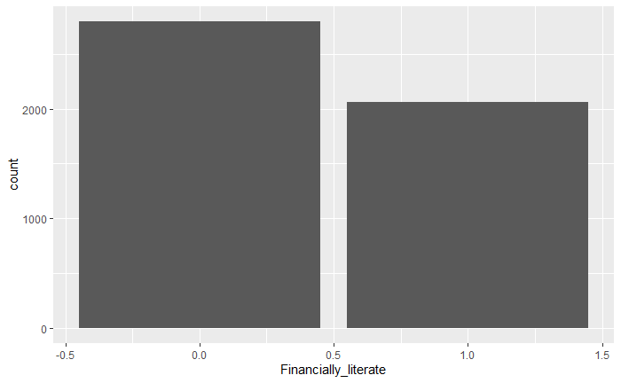

```r
ggplot(F.Literacy.11, aes(Financially_literate)) + geom_bar()
```

As can be seen from the plot there are more people financially illiterate under this definition than there are financially literate respondents. However, this distribution is not extremely skewed.

#Define the (multiple) dependent variables for the analyses

Defining portfolio diversification, and ability to collect cash-flows from that diversification.

This is done by combining the number of different asset classes respondents have (in the Asset.12 Data), with the number of sources people get cash from (Income.12).

```r
Portfolio.Data <- merge(Asset.12, Income.12, by = "nomem_encr")
Portfolio.Data <- na.omit(Portfolio.Data)
```

```r
Portfolio.Data$Diversification <- Portfolio.Data$ca12c078 + Portfolio.Data$ca12c005 + Portfolio.Data$ca12c006 + Portfolio.Data$ca12c007 +
  Portfolio.Data$ca12c008 + Portfolio.Data$ca12c011 + Portfolio.Data$ca12c079 + Portfolio.Data$ci12e144 + Portfolio.Data$ci12e152 +
  Portfolio.Data$ci12e153 + Portfolio.Data$ci12e177

#Diversification can be square root transformed with the below function
#Portfolio.Data$Diversification <- sqrt(Portfolio.Data$Diversification)
```

Plot of the distribution of financial diversification

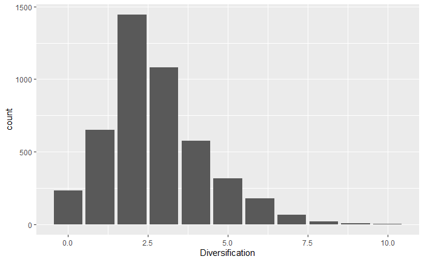

```r
ggplot(Portfolio.Data, aes(Diversification)) + geom_bar()
```

#Merge the datasets

```r
Portfolio.Data.number <- Portfolio.Data$nomem_encr
Portfolio.Data.Diversification <- Portfolio.Data$Diversification

Portfolio.Data <- as.data.frame(cbind(Portfolio.Data.number, Portfolio.Data.Diversification))
colnames(Portfolio.Data) <- c("nomem_encr", "Diversification")
```

Merging the data sets used to examine the relationship between financial literacy and financial diversification

```r
F.Literacy.11.C1 <- F.Literacy.11$nomem_encr
F.Literacy.11.FL <- F.Literacy.11$Financially_literate

F.Literacy.11 <- as.data.frame(cbind(F.Literacy.11.C1, F.Literacy.11.FL))
colnames(F.Literacy.11) <- c("nomem_encr", "Financially_literate")

Portfolio.Data <- merge(Portfolio.Data, F.Literacy.11, by = "nomem_encr")
Portfolio.Data <- merge(Portfolio.Data, Background.11, by = "nomem_encr")
Portfolio.Data <- merge(Portfolio.Data, Income.11, by = "nomem_encr")
Portfolio.Data <- merge(Portfolio.Data, Housing.11, by = "nomem_encr")
Portfolio.Data <- merge(Portfolio.Data, Work.11, by = "nomem_encr")
Portfolio.Data <- merge(Portfolio.Data, Personality.11, by = "nomem_encr")
Portfolio.Data <- merge(Portfolio.Data, Integration.11, by  = "nomem_encr")

#Remove Income.11 data that is directly related to definition of Diversification; that is, the outcome variable
Portfolio.Data$ci11d008 <- NULL
Portfolio.Data$ci11d144 <- NULL
Portfolio.Data$ci11d145 <- NULL
Portfolio.Data$ci11d146 <- NULL
Portfolio.Data$ci11d147 <- NULL
Portfolio.Data$ci11d148 <- NULL
Portfolio.Data$ci11d149 <- NULL
Portfolio.Data$ci11d150 <- NULL
Portfolio.Data$ci11d151 <- NULL
Portfolio.Data$ci11d152 <- NULL
Portfolio.Data$ci11d153 <- NULL
Portfolio.Data$ci11d175 <- NULL
Portfolio.Data$ci11d177 <- NULL

#Removing variables without variation
Portfolio.Data$cs11d293_9 <- NULL
Portfolio.Data$cs11d293_8 <- NULL
Portfolio.Data$cs11d292_9 <- NULL
Portfolio.Data$cs11d292_8 <- NULL
Portfolio.Data$cs11d290_9 <- NULL
Portfolio.Data$cs11d290_8 <- NULL
Portfolio.Data$woning_5 <- NULL
Portfolio.Data$woning_3 <- NULL
Portfolio.Data$aantalki_8 <- NULL
Portfolio.Data$aantalki_9 <- NULL
Portfolio.Data$ positie_9 <- NULL

#Remove NA's
Portfolio.Data <- na.omit(Portfolio.Data)
```

Setting the data in the right format for analysis

```r
Portfolio.Data[,1:601] <- as.numeric(unlist(list(Portfolio.Data[,1:601])))
```

```r
#y is outcome variable: dependent variable (Financial Diversification)
y.Diversification <- as.matrix(Portfolio.Data$Diversification)

#z is treatment variable for which inference is conducted: independent variable (Financial Literacy)
d.Diversification <- as.matrix(Portfolio.Data$Financially_literate)

#x is matrix of potential treatments
x.Diversification <- Portfolio.Data$Financially_literate
x2.Diversification<- Portfolio.Data
x2.Diversification$Financially_literate <- NULL

x.Diversification <- cbind(x.Diversification, x2.Diversification)

x.Diversification$Diversification <- NULL
#x.Diversification$Financially_literate <- NULL
x.Diversification$nomem_encr <- NULL

x.Diversification <- as.matrix(x.Diversification)
x2.Diversification <- as.matrix(x2.Diversification)
```

Post-double-selection procedure to assess the effect of the treatment financial literacy on financial diversification

```r
lasso.effect.Diversification = rlassoEffects(x.Diversification, y.Diversification, index = c("x.Diversification"),
                            method = "double selection", included = TRUE , I3 = NULL, post = FALSE, ... = 601)
```

```r
summary(lasso.effect.Diversification)
```

```
[1] "Estimates and significance testing of the effect of target variables"
                  Estimate. Std. Error t value Pr(>|t|)
x.Diversification   0.32900    0.07111   4.627 3.72e-06 ***
---
Signif. codes:  0 ‘***’ 0.001 ‘**’ 0.01 ‘*’ 0.05 ‘.’ 0.1 ‘ ’ 1
```

Specifying the post-double-selection Lasso procedure to identify the many potential causes of financial diversification

```r
lasso.effects.Diversification = rlassoEffects(x.Diversification, y.Diversification, index = c(1:ncol(x.Diversification)),
                            method = "double selection", included = TRUE , I3 = NULL, post = FALSE, ... = 601)
```

Summary of the post-double-selection Lasso procedure to identify the many potential causes of financail diversification

```r
summary(lasso.effects.Diversification)
```

```
[1] "Estimates and significance testing of the effect of target variables"
                   Estimate. Std. Error t value Pr(>|t|)
x.Diversification  3.290e-01  7.111e-02   4.627 3.72e-06 ***
leeftijd           1.296e-02  5.025e-03   2.578 0.009930 **
nettoink_f        -4.668e-07  4.369e-06  -0.107 0.914901
geslacht_2        -4.199e-01  1.084e-01  -3.872 0.000108 ***
positie_2         -1.324e-01  1.165e-01  -1.137 0.255672
positie_3          3.966e-02  1.903e-01   0.208 0.834876
positie_4                 NA  1.031e+13      NA       NA
positie_5          1.407e-02  3.959e-01   0.036 0.971655
positie_6                 NA  1.031e+13      NA       NA
positie_7                 NA  1.031e+13      NA       NA
aantalhh_2         2.805e-02  3.672e-01   0.076 0.939108
aantalhh_3        -4.929e-01  3.027e-01  -1.628 0.103502
aantalhh_4        -1.415e-01  2.725e-01  -0.519 0.603583
aantalhh_5         2.567e-01  8.618e-01   0.298 0.765800
aantalhh_6        -5.905e-01  2.058e-01  -2.870 0.004108 **
aantalhh_7         2.741e-01  1.035e+15   0.000 1.000000
aantalhh_8         6.792e-02  4.773e+17   0.000 1.000000
aantalhh_9                NA  1.031e+13      NA       NA
aantalki_2         1.892e-01  2.113e-01   0.895 0.370779
aantalki_3        -1.623e-01  3.253e-01  -0.499 0.617944
aantalki_4         4.277e-01  5.570e-01   0.768 0.442624
aantalki_5         2.741e-01  1.035e+15   0.000 1.000000
aantalki_6         6.792e-02  4.773e+17   0.000 1.000000
aantalki_7                NA  1.031e+13      NA       NA
burgstat_2         4.017e-01  3.654e-01   1.099 0.271674
burgstat_3         2.726e-01  1.543e-01   1.767 0.077250 .
burgstat_4        -7.630e-02  1.757e-01  -0.434 0.664092
burgstat_5         1.876e-01  1.552e-01   1.209 0.226800
woonvorm_2         1.213e-01  3.893e-01   0.312 0.755384
woonvorm_3         1.900e-01  3.603e-01   0.527 0.597963
woonvorm_4        -7.569e-01  4.064e-01  -1.862 0.062543 .
woonvorm_5         4.399e-02  5.513e-01   0.080 0.936402
woning_2          -6.388e-03  2.608e-01  -0.024 0.980457
woning_4          -2.315e-01  3.744e-01  -0.618 0.536351
sted_2             4.188e-02  1.077e-01   0.389 0.697458
sted_3             2.818e-02  1.133e-01   0.249 0.803688
sted_4            -1.368e-01  1.237e-01  -1.106 0.268909
sted_5             7.333e-02  1.328e-01   0.552 0.580819
```

[output cut: 548 more lines]

```
cs11d290_7         4.251e-01  2.120e-01   2.005 0.044920 *
cs11d292_2         3.378e-01  3.519e-01   0.960 0.337100
cs11d292_3         3.543e-01  3.359e-01   1.055 0.291545
cs11d292_4         2.425e-01  3.419e-01   0.709 0.478200
cs11d292_5         1.965e-01  3.265e-01   0.602 0.547267
cs11d292_6         4.720e-01  3.587e-01   1.316 0.188206
cs11d292_7         1.426e-01  3.453e-01   0.413 0.679706
cs11d293_2         2.229e-01  2.369e-01   0.941 0.346705
cs11d293_3         2.270e-01  2.290e-01   0.991 0.321599
cs11d293_4         2.022e-02  2.186e-01   0.093 0.926298
cs11d293_5         2.165e-01  2.037e-01   1.063 0.287952
cs11d293_6         2.634e-01  2.084e-01   1.264 0.206306
cs11d293_7         1.669e-01  2.093e-01   0.797 0.425259
---
Signif. codes:  0 ‘***’ 0.001 ‘**’ 0.01 ‘*’ 0.05 ‘.’ 0.1 ‘ ’ 1
```

#Define the (multiple) dependent variables for the analyses

This is done by combining the number of different asset classes respondents have (in the Asset.12 Data), with the number of sources people get cash from (Income.12).

```r
Investment.Data <- merge(Asset.12, Income.12, by = "nomem_encr")
Investment.Data <- na.omit(Investment.Data)
```

```r
Investment.Data$Investments <- Investment.Data$ca12c006 + Investment.Data$ca12c007 + Investment.Data$ci12e144 +
  Investment.Data$ci12e152 + Investment.Data$ci12e153

#Invsetments can be square root transformed with the below function
#Investment.Data$Investments <- sqrt(Investment.Data$Investments)
```

Plot of the distribution of financial investments

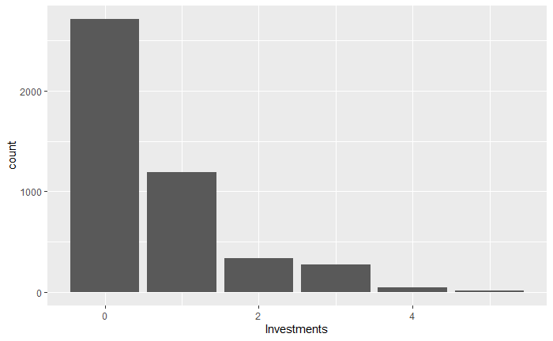

```r
ggplot(Investment.Data, aes(Investments)) + geom_bar()
```

```r
Investment.Data.number <- Investment.Data$nomem_encr
Investment.Data.Investments <- Investment.Data$Investments

Investment.Data <- as.data.frame(cbind(Investment.Data.number, Investment.Data.Investments))
colnames(Investment.Data) <- c("nomem_encr", "Investments")
```

Merging data sets to for the analysis of the effect of financial literacy on investments

```r
F.Literacy.11.C1 <- F.Literacy.11$nomem_encr
F.Literacy.11.FL <- F.Literacy.11$Financially_literate

F.Literacy.11 <- as.data.frame(cbind(F.Literacy.11.C1, F.Literacy.11.FL))
colnames(F.Literacy.11) <- c("nomem_encr", "Financially_literate")

Investment.Data <- merge(Investment.Data, F.Literacy.11, by = "nomem_encr")
Investment.Data <- merge(Investment.Data, Background.11, by = "nomem_encr")
Investment.Data <- merge(Investment.Data, Income.11, by = "nomem_encr")
Investment.Data <- merge(Investment.Data, Housing.11, by = "nomem_encr")
Investment.Data <- merge(Investment.Data, Work.11, by = "nomem_encr")
Investment.Data <- merge(Investment.Data, Personality.11, by = "nomem_encr")
Investment.Data <- merge(Investment.Data, Integration.11, by  = "nomem_encr")

#Remove Income.11 data that is directly related to definition of Diversification
Investment.Data$ci11d144 <- NULL
Investment.Data$ci11d152 <- NULL
Investment.Data$ci11d153 <- NULL

#Removing variables without variation
Investment.Data$cs11d293_9 <- NULL
Investment.Data$cs11d293_8 <- NULL
Investment.Data$cs11d292_9 <- NULL
Investment.Data$cs11d292_8 <- NULL
Investment.Data$cs11d290_9 <- NULL
Investment.Data$cs11d290_8 <- NULL
Investment.Data$woning_5 <- NULL
Investment.Data$woning_3 <- NULL
Investment.Data$aantalki_8 <- NULL
Investment.Data$aantalki_9 <- NULL
Investment.Data$ positie_9 <- NULL

#Remove NA's
Investment.Data <- na.omit(Investment.Data)
```

Setting the data in the right format for analysis

```r
Investment.Data[,1:611] <- as.numeric(unlist(list(Investment.Data[,1:611])))
```

```r
#y is outcome variable: dependent variable (Financial Diversification)
y.Investment <- as.matrix(Investment.Data$Investments)

#z is treatment variable for which inference is conducted: independent variable (Financial Literacy)
d.Investment <- as.matrix(Investment.Data$Financially_literate)

#x is matrix of potential treatments
x.Investment <- Investment.Data$Financially_literate
x2.Investment<- Investment.Data
x2.Investment$Financially_literate <- NULL

x.Investment <- cbind(x.Investment, x2.Investment)

x.Investment$Investments <- NULL
x.Investment$nomem_encr <- NULL

x.Investment <- as.matrix(x.Investment)
x2.Investment <- as.matrix(x2.Investment)
```

Post-double-selection Lasso procedure to assess the effect of the treatment financial literacy on investments

```r
lasso.effect.Investments = rlassoEffects(x.Investment, y.Investment, index = c("x.Investment"),
                            method = "double selection", included = TRUE , I3 = NULL, post = FALSE, ... = 610)
```

```r
summary(lasso.effect.Investments)
```

```
[1] "Estimates and significance testing of the effect of target variables"
             Estimate. Std. Error t value Pr(>|t|)
x.Investment   0.24320    0.04436   5.482  4.2e-08 ***
---
Signif. codes:  0 ‘***’ 0.001 ‘**’ 0.01 ‘*’ 0.05 ‘.’ 0.1 ‘ ’ 1
```

The post-double-selection Lasso procedure to identify the many potential causes of investments

```r
lasso.effects.Investments = rlassoEffects(x.Investment, y.Investment, index = c(1:ncol(x.Investment)),
                            method = "double selection", included = TRUE , I3 = NULL, post = FALSE, ... = 610)
```

Summary of the post-double-selection Lasso procedure to identify the many potential causes of investments

```r
summary(lasso.effects.Investments)
```

```
[1] "Estimates and significance testing of the effect of target variables"
                   Estimate. Std. Error t value Pr(>|t|)
x.Investment       2.432e-01  4.436e-02   5.482 4.20e-08 ***
leeftijd           7.077e-03  2.987e-03   2.369 0.017821 *
nettoink_f        -6.637e-07  1.577e-06  -0.421 0.673861
geslacht_2        -1.801e-01  7.096e-02  -2.538 0.011139 *
positie_2         -1.662e-02  6.976e-02  -0.238 0.811656
positie_3         -3.030e-02  1.169e-01  -0.259 0.795394
positie_4                 NA  7.793e+12      NA       NA
positie_5          1.455e+00  2.508e-01   5.804 6.48e-09 ***
positie_6                 NA  7.793e+12      NA       NA
positie_7                 NA  7.793e+12      NA       NA
aantalhh_2        -3.233e-01  2.483e-01  -1.302 0.192810
aantalhh_3         2.311e-01  1.887e-01   1.225 0.220660
aantalhh_4         3.043e-01  1.549e-01   1.964 0.049508 *
aantalhh_5         6.273e-01  5.332e-01   1.177 0.239383
aantalhh_6         3.133e-01  6.854e-02   4.570 4.87e-06 ***
aantalhh_7        -5.828e-01  4.351e+14   0.000 1.000000
aantalhh_8         6.059e-02  2.681e+17   0.000 1.000000
aantalhh_9                NA  7.793e+12      NA       NA
aantalki_2        -2.960e-02  1.447e-01  -0.205 0.837903
aantalki_3         3.232e-01  1.558e-01   2.075 0.037987 *
aantalki_4        -2.043e-01  2.832e-01  -0.721 0.470711
aantalki_5        -5.828e-01  4.351e+14   0.000 1.000000
aantalki_6         6.059e-02  2.681e+17   0.000 1.000000
aantalki_7                NA  7.793e+12      NA       NA
burgstat_2         5.514e-01  2.729e-01   2.021 0.043322 *
burgstat_3         2.204e-01  9.607e-02   2.294 0.021779 *
burgstat_4         4.576e-02  1.098e-01   0.417 0.676806
burgstat_5         2.529e-01  9.711e-02   2.604 0.009205 **
woonvorm_2         3.189e-01  2.638e-01   1.209 0.226748
woonvorm_3        -4.141e-01  1.763e-01  -2.349 0.018840 *
woonvorm_4         7.284e-02  2.657e-01   0.274 0.783944
woonvorm_5         5.593e-02  3.756e-01   0.149 0.881632
woning_2          -1.518e-01  2.370e-01  -0.641 0.521801
woning_4          -3.786e-01  2.338e-01  -1.619 0.105441
sted_2             3.956e-02  6.614e-02   0.598 0.549784
sted_3            -1.117e-02  6.899e-02  -0.162 0.871358
sted_4            -3.613e-02  7.685e-02  -0.470 0.638250
sted_5            -2.005e-02  8.096e-02  -0.248 0.804402
```

[output cut: 558 more lines]

```
cs11d290_7         1.915e-01  1.250e-01   1.532 0.125399
cs11d292_2         2.397e-01  1.395e-01   1.718 0.085785 .
cs11d292_3         2.092e-01  1.305e-01   1.603 0.108980
cs11d292_4         1.086e-01  1.309e-01   0.830 0.406638
cs11d292_5         1.433e-01  1.188e-01   1.207 0.227611
cs11d292_6         2.337e-01  1.478e-01   1.582 0.113698
cs11d292_7         2.173e-01  1.368e-01   1.589 0.112117
cs11d293_2        -5.906e-02  1.923e-01  -0.307 0.758783
cs11d293_3        -7.334e-02  1.767e-01  -0.415 0.678016
cs11d293_4        -2.630e-01  1.789e-01  -1.470 0.141451
cs11d293_5        -1.677e-01  1.726e-01  -0.971 0.331394
cs11d293_6        -2.368e-01  1.793e-01  -1.321 0.186632
cs11d293_7        -2.824e-01  1.678e-01  -1.683 0.092437 .
---
Signif. codes:  0 ‘***’ 0.001 ‘**’ 0.01 ‘*’ 0.05 ‘.’ 0.1 ‘ ’ 1
```

#Defining Risk Appetite

```r
Risk.12$ga12a001[is.na(Risk.12$ga12a001)] <- 0
Risk.12$ga12a002[is.na(Risk.12$ga12a002)] <- 0
Risk.12$ga12a003[is.na(Risk.12$ga12a003)] <- 0

Risk.12$option_1 <- ifelse(Risk.12$ga12a001 >= 34, 1, 0)
Risk.12$option_2 <- ifelse(Risk.12$ga12a002 >= 34, 10, 0)
Risk.12$option_3 <- ifelse(Risk.12$ga12a003 >= 34, 30, 0)

Risk.12$option <- Risk.12$option_1 + Risk.12$option_2 + Risk.12$option_3

Risk.12$option_score_1 <- ifelse(Risk.12$option == 1, 1, 0)
Risk.12$option_score_2 <- ifelse(Risk.12$option == 11, 2, 0)
Risk.12$option_score_3 <- ifelse(Risk.12$option == 10, 3, 0)
Risk.12$option_score_4 <- ifelse(Risk.12$option == 40, 4, 0)
Risk.12$option_score_5 <- ifelse(Risk.12$option == 30, 5, 0)

Risk.12$options <- Risk.12$option_score_1 + Risk.12$option_score_2 + Risk.12$option_score_3 + Risk.12$option_score_4 + Risk.12$option_score_5

Risk.12$ga12a004[Risk.12$ga12a004 == 1] <- 10
Risk.12$ga12a004[Risk.12$ga12a004 == 2] <- 20
Risk.12$ga12a004[Risk.12$ga12a004 == 4] <- 40
Risk.12$ga12a004[Risk.12$ga12a004 == 5] <- 50

Risk.12$ga12a004[Risk.12$ga12a004 == 10] <- 5
Risk.12$ga12a004[Risk.12$ga12a004 == 20] <- 4
Risk.12$ga12a004[Risk.12$ga12a004 == 40] <- 2
Risk.12$ga12a004[Risk.12$ga12a004 == 50] <- 1

Risk.12$Risk <- Risk.12$ga12a004 + Risk.12$ga12a005 + Risk.12$options

Risk.id <- as.data.frame(Risk.12$nomem_encr)
Risk.dt <- as.data.frame(Risk.12$Risk)

Risk.Data <- cbind(Risk.id, Risk.dt)
colnames(Risk.Data) <- c("nomem_encr", "Risk")

Risk.Data <- na.omit(Risk.Data)
Risk.Data$Risk <- Risk.Data$Risk - 2
```

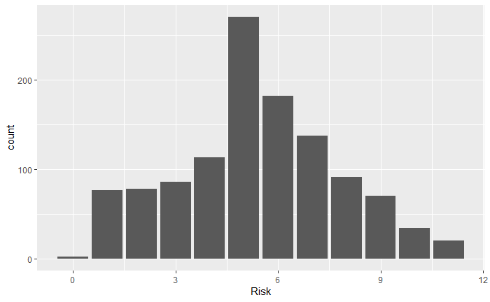

```r
ggplot(Risk.Data, aes(Risk)) + geom_bar()
```

Merging the data sets for the analysis of Risk preferences

```r
F.Literacy.11.C1 <- F.Literacy.11$nomem_encr
F.Literacy.11.FL <- F.Literacy.11$Financially_literate

F.Literacy.11 <- as.data.frame(cbind(F.Literacy.11.C1, F.Literacy.11.FL))
colnames(F.Literacy.11) <- c("nomem_encr", "Financially_literate")

Risk.Data <- merge(Risk.Data, F.Literacy.11, by = "nomem_encr")
Risk.Data <- merge(Risk.Data, Background.11, by = "nomem_encr")
Risk.Data <- merge(Risk.Data, Income.11, by = "nomem_encr")
Risk.Data <- merge(Risk.Data, Housing.11, by = "nomem_encr")
Risk.Data <- merge(Risk.Data, Work.11, by = "nomem_encr")
Risk.Data <- merge(Risk.Data, Personality.11, by = "nomem_encr")
Risk.Data <- merge(Risk.Data, Integration.11, by  = "nomem_encr")

#Removing variables without variation
Risk.Data$cs11d293_9 <- NULL
Risk.Data$cs11d293_8 <- NULL
Risk.Data$cs11d292_9 <- NULL
Risk.Data$cs11d292_8 <- NULL
Risk.Data$cs11d290_9 <- NULL
Risk.Data$cs11d290_8 <- NULL
Risk.Data$woning_5 <- NULL
Risk.Data$woning_3 <- NULL
Risk.Data$aantalki_8 <- NULL
Risk.Data$aantalki_9 <- NULL
Risk.Data$ positie_9 <- NULL

#Remove NA's
Risk.Data <- na.omit(Risk.Data)
```

Setting the data in the right format for analysis

```r
Risk.Data[,1:614] <- as.numeric(unlist(list(Risk.Data[,1:614])))
```

```r
#y is outcome variable: dependent variable (Financial Risk)
y.Risk <- as.matrix(Risk.Data$Risk)

#z is treatment variable for which inference is conducted: independent variable (Financial Literacy)
d.Risk <- as.matrix(Risk.Data$Financially_literate)

#x is matrix of potential treatments
x.Risk <- Risk.Data$Financially_literate
x2.Risk<- Risk.Data
x2.Risk$Financially_literate <- NULL

x.Risk <- cbind(x.Risk, x2.Risk)

x.Risk$Risk <- NULL
#x.Risk$Financially_literate <- NULL
x.Risk$nomem_encr <- NULL

x.Risk <- as.matrix(x.Risk)
x2.Risk <- as.matrix(x2.Risk)
```

A post-double-selection Lasso procedure to establish the treatment effect of finanical literacy on risk preferences

```r
lasso.effect.Risk.Final = rlassoEffects(x.Risk, y.Risk, index = c("x.Risk"),
                            method = "double selection", included = TRUE , I3 = NULL, post = FALSE, ... = 612)
```

Summary of the effect of financial literacy on risk preferences

```r
summary(lasso.effect.Risk.Final)
```

```
[1] "Estimates and significance testing of the effect of target variables"
       Estimate. Std. Error t value Pr(>|t|)
x.Risk  -0.07831    0.31457  -0.249    0.803
```

The post-double-selection Lasso procedure to identify the many potential causes of risk preferences

```r
lasso.effects.Risk.Final = rlassoEffects(x.Risk, y.Risk, index = c(1:ncol(x.Risk)),
                            method = "double selection", included = TRUE , I3 = NULL, post = FALSE, ... = 612)
```

```
NaNs produced
```

Summary of the post-double-selection Lasso procedure to identify the many potential causes of risk preferences

```r
summary(lasso.effects.Risk.Final)
```

```
[1] "Estimates and significance testing of the effect of target variables"
                   Estimate. Std. Error t value Pr(>|t|)
x.Risk            -7.831e-02  3.146e-01  -0.249 0.803409
leeftijd           6.095e-03  2.314e-02   0.263 0.792274
nettoink_f        -1.799e-05  3.100e-06  -5.805 6.42e-09 ***
geslacht_2        -3.281e-01  4.967e-01  -0.661 0.508806
positie_2          6.971e-01  4.606e-01   1.513 0.130198
positie_3          1.026e+00  7.824e-01   1.312 0.189577
positie_4                 NA  1.071e+13      NA       NA
positie_5         -4.097e-01  1.548e+14   0.000 1.000000
positie_6                 NA  1.071e+13      NA       NA
positie_7                 NA  1.071e+13      NA       NA
aantalhh_2         1.758e+00  1.054e+00   1.668 0.095237 .
aantalhh_3        -1.477e+00  1.280e+00  -1.154 0.248705
aantalhh_4        -2.834e+00  2.869e+00  -0.988 0.323233
aantalhh_5        -1.257e+00  1.928e+13   0.000 1.000000
aantalhh_6        -4.562e-01  1.132e+15   0.000 1.000000
aantalhh_7                NA  1.071e+13      NA       NA
aantalhh_8                NA  1.071e+13      NA       NA
aantalhh_9                NA  1.071e+13      NA       NA
aantalki_2         2.021e+00  1.241e+00   1.629 0.103374
aantalki_3        -1.257e+00  1.928e+13   0.000 1.000000
aantalki_4        -4.562e-01  1.132e+15   0.000 1.000000
aantalki_5                NA  1.071e+13      NA       NA
aantalki_6                NA  1.071e+13      NA       NA
aantalki_7                NA  1.071e+13      NA       NA
burgstat_2                NA  1.071e+13      NA       NA
burgstat_3        -2.522e-01  5.149e-01  -0.490 0.624211
burgstat_4         8.246e-01  6.277e-01   1.314 0.188936
burgstat_5         6.627e-01  4.907e-01   1.351 0.176847
woonvorm_2        -9.365e-01  1.056e+00  -0.887 0.375018
woonvorm_3         1.316e+00  1.362e+00   0.966 0.334174
woonvorm_4         1.265e+00  9.163e-01   1.381 0.167323
woonvorm_5         8.930e-01  3.119e-01   2.863 0.004198 **
woning_2          -6.354e-01  7.305e-01  -0.870 0.384356
woning_4           1.651e+00  7.697e-01   2.145 0.031923 *
sted_2             4.398e-01  4.234e-01   1.039 0.298986
sted_3             6.735e-01  4.343e-01   1.551 0.121013
sted_4             3.254e-01  4.565e-01   0.713 0.475979
sted_5             1.084e+00  5.123e-01   2.115 0.034430 *
```

[output cut: 561 more lines]

```
cs11d290_7         8.930e-01  8.699e-01   1.027 0.304586
cs11d292_2         1.534e-01  1.085e+00   0.141 0.887525
cs11d292_3        -3.016e-01  1.054e+00  -0.286 0.774768
cs11d292_4        -9.021e-01  1.033e+00  -0.873 0.382535
cs11d292_5        -2.581e-01  1.008e+00  -0.256 0.797847
cs11d292_6        -1.692e+00  1.151e+00  -1.470 0.141649
cs11d292_7        -5.100e-01  1.045e+00  -0.488 0.625571
cs11d293_2        -9.291e-01  9.730e-01  -0.955 0.339633
cs11d293_3        -4.587e-01  8.409e-01  -0.546 0.585389
cs11d293_4        -8.170e-01  1.039e+00  -0.787 0.431528
cs11d293_5        -7.787e-01  8.205e-01  -0.949 0.342579
cs11d293_6        -3.236e-01  8.762e-01  -0.369 0.711922
cs11d293_7        -7.700e-01  8.136e-01  -0.946 0.343965
---
Signif. codes:  0 ‘***’ 0.001 ‘**’ 0.01 ‘*’ 0.05 ‘.’ 0.1 ‘ ’ 1
```

#Save the results as an RData file

```r
save(lasso.effect.Diversification, lasso.effects.Diversification, lasso.effect.Investments, lasso.effects.Investments,
     lasso.effect.Risk.Final, lasso.effects.Risk.Final, file = "Thesis_Results_Final.RData")
```

Save the globa environment as an RData file

```r
save.image("Thesis_Final_Environment.RData")
```